# DSCC Dynamics

Carsten Kirkeby

februar 26, 2019

```r
knitr::opts_knit$set(root.dir = 'P:/Mastitis/EMCoMast/EMCoMAST_data/DCC_data/DCC_2')
load("P:/Mastitis/EMCoMast/EMCoMAST_data/DCC_data/DCC_2/alldata_read_in_26022019.Rdata")
```

## False negative corrections

We here look at how long the individual cows have been infected with each pathogen group, detected using BC. Prior to analysis, we corrected the (assumed) false negative records to positive (if one negative result was found between two positive results). In herd 1 there were **32** corrections for Major pathogens, **80** corrections for Minor pathogens and **12** for Other pathogens. In herd 2 there were **18** corrections for Major pathogens, **62** for Minor pathogens and **17** for Other pathogens.

### Inclusion criteria

Should we use the records with SCC < 50K?

We use all of it where SCC is not missing and above 0. We then set missing DSCC values to half of the lowest value (within the same herd). A practical solution that *kind of* reflect the DSCC level in the herd.

The minimum DSCC for Herd 1 is **34.05** and for Herd 2 it is **25.09**.

## New / Chronic infections

Then we identify the chronic cows and the new infections. New infections are positive records where there was a negative record in the previous sampling. Chronic infections are positive records where the previous record was positive.

Does this make sense to do on cow level, or should we go down to quarter level?

```r
alldata.backup <- alldata

# First we identify those that are infected in general:
alldata[ ,inf:=numeric(.N) ]
alldata$inf[alldata$major==1 | alldata$minor==1 | alldata$other==1 ] <- 1
#table(alldata$inf)

# Create new columns:
library(data.table)
alldata[ ,newinf.maj:=numeric(.N) ]
alldata[ ,newinf.min:=numeric(.N) ]
alldata[ ,newinf.oth:=numeric(.N) ]
alldata[ ,chronic.maj:=numeric(.N) ]
alldata[ ,chronic.min:=numeric(.N) ]
alldata[ ,chronic.oth:=numeric(.N) ]

# kowz <- unique(alldata$Cow.ID[alldata$major2==1])
#
# N<- N+1
# i <- kowz[N]
# alldata[Cow.ID==i]$minor

# Ko 2665 er et godt eksempel for major.
# Ko 3047 er et godt eksempel for minor og other (1 ny forbigaaende inf)

# Function to identify new infections:
# Først negativ og så positive = new infection
f.new <- function(x)
  {
    y <- rep(0,length(x))
    y[c(NA,diff(x))%in%1 & x==1] <- 1
    return(y)
  }

# Function to identify chronic infections:
# Smittet to gange i træk = chronic
f.chronic <- function(x)
  {
    y <- rep(0,length(x))
    y[c(NA,diff(x))%in%0 & x==1] <- 1
    return(y)
  }

#Et eksempel til at bygge med:
#i <- 2665
#i <- 3047

# We loop over the cows and find the new infections and the chronic cases:
kowz <- unique(alldata$Cow.ID[alldata$major2==1])
for(i in kowz)
{
  tmp.maj <- alldata[Cow.ID==i]$major
  tmp.min <- alldata[Cow.ID==i]$minor
  tmp.oth <- alldata[Cow.ID==i]$other

  alldata[Cow.ID==i]$newinf.maj <- f.new(tmp.maj)
  alldata[Cow.ID==i]$newinf.min <- f.new(tmp.min)
  alldata[Cow.ID==i]$newinf.oth <- f.new(tmp.oth)

  alldata[Cow.ID==i]$chronic.maj <- f.chronic(tmp.maj)
  alldata[Cow.ID==i]$chronic.min <- f.chronic(tmp.min)
  alldata[Cow.ID==i]$chronic.oth <- f.chronic(tmp.oth)

}

# Then we look at all groups together. Note that a cow can be newly infected
# with one pathogen and chronic with another at the same time.

# Create new columns:
alldata[ ,newinf:=numeric(.N) ]
alldata[ ,chronic:=numeric(.N) ]

alldata$newinf[as.logical(alldata$newinf.maj) | as.logical(alldata$newinf.min) |
                 as.logical(alldata$newinf.oth)] <- 1
#table(alldata$newinf)

alldata$chronic[as.logical(alldata$chronic.maj) | as.logical(alldata$chronic.min) |
                 as.logical(alldata$chronic.oth)] <- 1
#table(alldata$chronic)

# Der er 205 køer som er både chronic og newinf på samme tid:
#table(rowSums(cbind(alldata$chronic, alldata$newinf)))

# For the table:
newinf <- c("New infections",sum(alldata$newinf.maj[alldata$Herd%in%1]),
          sum(alldata$newinf.min[alldata$Herd%in%1]),
          sum(alldata$newinf.oth[alldata$Herd%in%1]),
          sum(alldata$newinf.maj[alldata$Herd%in%2]),
          sum(alldata$newinf.min[alldata$Herd%in%2]),
          sum(alldata$newinf.oth[alldata$Herd%in%2])
)
chron <- c("Chronic infections",sum(alldata$chronic.maj[alldata$Herd%in%1]),
          sum(alldata$chronic.min[alldata$Herd%in%1]),
          sum(alldata$chronic.oth[alldata$Herd%in%1]),
          sum(alldata$chronic.maj[alldata$Herd%in%2]),
          sum(alldata$chronic.min[alldata$Herd%in%2]),
          sum(alldata$chronic.oth[alldata$Herd%in%2])
)
paths <- c("","Major","Minor","Other","Major","Minor","Other")
spacer <- c("  ","  ","  ","  ","  ","  ","  ")
Herds <- c("","Herd1","","","Herd2","","")

tmp <- cbind(Herds, spacer, paths, spacer, newinf, spacer, chron)
colnames(tmp) <- NULL
# library(kableExtra)
# kable(dt, format = "html", caption = "Number of infections in the data") %>%
#   kable_styling(bootstrap_options = "striped",
#                 full_width = F) %>%
#   add_header_above(c(" ", "Group 1" = 2, "Group 2[note]" = 2)) %>%
#   add_footnote(c("table footnote"))
library(kableExtra)
library(tidyverse)
#kable(tmp)
kable(tmp, format = "html", caption = "Table 1: Number of new/chronic infections in the data") %>%
  kable_styling(bootstrap_options = "striped",
                 full_width = F)
```

Table 1: Number of new/chronic infections in the data

|  |  |  |  | New infections |  | Chronic infections |
| --- | --- | --- | --- | --- | --- | --- |
| Herd1 |  | Major |  | 24 |  | 816 |
|  |  | Minor |  | 97 |  | 498 |
|  |  | Other |  | 62 |  | 56 |
| Herd2 |  | Major |  | 22 |  | 158 |
|  |  | Minor |  | 20 |  | 241 |
|  |  | Other |  | 15 |  | 13 |

## Sensitivity and specificity SCC

We calculate the sensitivity and specificity for using a fixed threshold for SCC and DSCC separately. and in combination.

Herd 1:

```r
cutoff.scc <- 200
cutoffs <- seq(50,400,50)

dt <- alldata[Herd==1]

res.tmp <- as.data.frame(matrix(NA, ncol=0, nrow=5))

for(cutoff.scc in cutoffs)
{
  # Create dataframe:
  tmp <- as.data.frame(matrix(NA, nrow=3, ncol=2))
  colnames(tmp) <- c("TP", "TN")
  rownames(tmp) <- c("SCC+", "SCC-", " ")
  # Fill the table:
  tmp[1,1] <- length(dt[dt$SCC>=cutoff.scc & dt$inf%in%1]$SCC)
  tmp[1,2] <- length(dt[dt$SCC>=cutoff.scc & dt$inf%in%0]$SCC)
  tmp[2,1] <- length(dt[dt$SCC<cutoff.scc & dt$inf%in%1]$SCC)
  tmp[2,2] <- length(dt[dt$SCC<cutoff.scc & dt$inf%in%0]$SCC)
  #tmp
  tmp.sens <- tmp[1,1] / sum(tmp[1,1],tmp[2,1])
  tmp.spec <- tmp[2,2] / sum(tmp[1,2],tmp[2,2])
  tmp[3,] <- c("Se:", "Sp:")
  tmp[4,] <- round(c(tmp.sens,tmp.spec),2)
  tmp <- rbind(c(cutoff.scc, ""),tmp)
  res.tmp <- cbind(res.tmp,tmp)
}
colnames(res.tmp) <- NULL
rownames(res.tmp)[1] <- "Cutoff"
rownames(res.tmp)[5] <- "  "

res.tmp2 <- rbind(c(res.tmp[1,]), rep(c("TP", "TN"), length(cutoffs)), res.tmp[2:5,])
rownames(res.tmp2)[1] <- "Cutoff"
rownames(res.tmp2)[2] <- "   "

library(kableExtra)
library(tidyverse)
kable(res.tmp2, format = "html", caption = "Table 2: Herd 1, 2x2 table for SCC alone") %>%
  kable_styling(bootstrap_options = "striped",
                 full_width = F ) %>%
  row_spec(2, bold = T) %>%
  row_spec(5, bold = T) %>%
  row_spec(1:6, color = "black")
```

Table 2: Herd 1, 2x2 table for SCC alone

| Cutoff | 50 |  | 100 |  | 150 |  | 200 |  | 250 |  | 300 |  | 350 |  | 400 |  |
| --- | --- | --- | --- | --- | --- | --- | --- | --- | --- | --- | --- | --- | --- | --- | --- | --- |
|  | TP | TN | TP | TN | TP | TN | TP | TN | TP | TN | TP | TN | TP | TN | TP | TN |
| SCC+ | 1177 | 37 | 920 | 14 | 754 | 8 | 611 | 6 | 504 | 4 | 431 | 3 | 375 | 2 | 323 | 2 |
| SCC- | 1 | 1 | 258 | 24 | 424 | 30 | 567 | 32 | 674 | 34 | 747 | 35 | 803 | 36 | 855 | 36 |
|  | Se: | Sp: | Se: | Sp: | Se: | Sp: | Se: | Sp: | Se: | Sp: | Se: | Sp: | Se: | Sp: | Se: | Sp: |
|  | 1 | 0.03 | 0.78 | 0.63 | 0.64 | 0.79 | 0.52 | 0.84 | 0.43 | 0.89 | 0.37 | 0.92 | 0.32 | 0.95 | 0.27 | 0.95 |

Looking at Herd 2:

```r
cutoff.scc <- 200
cutoffs <- seq(50,400,50)

dt <- alldata[Herd==2]

res.tmp <- as.data.frame(matrix(NA, ncol=0, nrow=5))

for(cutoff.scc in cutoffs)
{
  # Create dataframe:
  tmp <- as.data.frame(matrix(NA, nrow=3, ncol=2))
  colnames(tmp) <- c("TP", "TN")
  rownames(tmp) <- c("SCC+", "SCC-", " ")
  # Fill the table:
  tmp[1,1] <- length(dt[dt$SCC>=cutoff.scc & dt$inf%in%1]$SCC)
  tmp[1,2] <- length(dt[dt$SCC>=cutoff.scc & dt$inf%in%0]$SCC)
  tmp[2,1] <- length(dt[dt$SCC<cutoff.scc & dt$inf%in%1]$SCC)
  tmp[2,2] <- length(dt[dt$SCC<cutoff.scc & dt$inf%in%0]$SCC)
  #tmp
  tmp.sens <- tmp[1,1] / sum(tmp[1,1],tmp[2,1])
  tmp.spec <- tmp[2,2] / sum(tmp[1,2],tmp[2,2])
  tmp[3,] <- c("Se:", "Sp:")
  tmp[4,] <- round(c(tmp.sens,tmp.spec),2)
  tmp <- rbind(c(cutoff.scc, ""),tmp)
  res.tmp <- cbind(res.tmp,tmp)
}
colnames(res.tmp) <- NULL
rownames(res.tmp)[1] <- "Cutoff"
rownames(res.tmp)[5] <- "  "

res.tmp2 <- rbind(c(res.tmp[1,]), rep(c("TP", "TN"), length(cutoffs)), res.tmp[2:5,])
rownames(res.tmp2)[1] <- "Cutoff"
rownames(res.tmp2)[2] <- "   "

library(kableExtra)
library(tidyverse)
kable(res.tmp2, format = "html", caption = "Table 2: Herd 2, 2x2 table for SCC alone") %>%
  kable_styling(bootstrap_options = "striped",
                 full_width = F ) %>%
  row_spec(2, bold = T) %>%
  row_spec(5, bold = T) %>%
  row_spec(1:6, color = "black")
```

Table 2: Herd 2, 2x2 table for SCC alone

| Cutoff | 50 |  | 100 |  | 150 |  | 200 |  | 250 |  | 300 |  | 350 |  | 400 |  |
| --- | --- | --- | --- | --- | --- | --- | --- | --- | --- | --- | --- | --- | --- | --- | --- | --- |
|  | TP | TN | TP | TN | TP | TN | TP | TN | TP | TN | TP | TN | TP | TN | TP | TN |
| SCC+ | 2517 | 160 | 1851 | 72 | 1361 | 56 | 1021 | 40 | 791 | 29 | 613 | 26 | 486 | 20 | 395 | 16 |
| SCC- | 0 | 0 | 666 | 88 | 1156 | 104 | 1496 | 120 | 1726 | 131 | 1904 | 134 | 2031 | 140 | 2122 | 144 |
|  | Se: | Sp: | Se: | Sp: | Se: | Sp: | Se: | Sp: | Se: | Sp: | Se: | Sp: | Se: | Sp: | Se: | Sp: |
|  | 1 | 0 | 0.74 | 0.55 | 0.54 | 0.65 | 0.41 | 0.75 | 0.31 | 0.82 | 0.24 | 0.84 | 0.19 | 0.88 | 0.16 | 0.9 |

## Sensitivity and specificity DSCC

Then we look at DSCC

Herd 1:

```r
cutoffs <- seq(54,68,2)

dt <- alldata[Herd==1]

res.tmp <- as.data.frame(matrix(NA, ncol=0, nrow=5))

for(cutoff.dscc in cutoffs)
{
  # Create dataframe:
  tmp <- as.data.frame(matrix(NA, nrow=3, ncol=2))
  colnames(tmp) <- c("TP", "TN")
  rownames(tmp) <- c("DSCC+", "DSCC-", " ")
  # Fill the table:
  tmp[1,1] <- length(dt[dt$DSCC>=cutoff.dscc & dt$inf%in%1]$DSCC)
  tmp[1,2] <- length(dt[dt$DSCC>=cutoff.dscc & dt$inf%in%0]$DSCC)
  tmp[2,1] <- length(dt[dt$DSCC<cutoff.dscc & dt$inf%in%1]$DSCC)
  tmp[2,2] <- length(dt[dt$DSCC<cutoff.dscc & dt$inf%in%0]$DSCC)
  #tmp
  tmp.sens <- tmp[1,1] / sum(tmp[1,1],tmp[2,1])
  tmp.spec <- tmp[2,2] / sum(tmp[1,2],tmp[2,2])
  tmp[3,] <- c("Se:", "Sp:")
  tmp[4,] <- round(c(tmp.sens,tmp.spec),2)
  tmp <- rbind(c(cutoff.dscc, ""),tmp)
  res.tmp <- cbind(res.tmp,tmp)
}
colnames(res.tmp) <- NULL
rownames(res.tmp)[1] <- "Cutoff"
rownames(res.tmp)[5] <- "  "

res.tmp2 <- rbind(c(res.tmp[1,]), rep(c("TP", "TN"), length(cutoffs)), res.tmp[2:5,])
rownames(res.tmp2)[1] <- "Cutoff"
rownames(res.tmp2)[2] <- "   "

library(kableExtra)
library(tidyverse)
kable(res.tmp2, format = "html", caption = "Table 2: Herd 1, 2x2 table for DSCC alone") %>%
  kable_styling(bootstrap_options = "striped",
                 full_width = F ) %>%
  row_spec(2, bold = T) %>%
  row_spec(5, bold = T) %>%
  row_spec(1:6, color = "black")
```

Table 2: Herd 1, 2x2 table for DSCC alone

| Cutoff | 54 |  | 56 |  | 58 |  | 60 |  | 62 |  | 64 |  | 66 |  | 68 |  |
| --- | --- | --- | --- | --- | --- | --- | --- | --- | --- | --- | --- | --- | --- | --- | --- | --- |
|  | TP | TN | TP | TN | TP | TN | TP | TN | TP | TN | TP | TN | TP | TN | TP | TN |
| DSCC+ | 1102 | 30 | 1081 | 30 | 1058 | 28 | 1031 | 26 | 988 | 26 | 920 | 24 | 865 | 21 | 794 | 19 |
| DSCC- | 76 | 8 | 97 | 8 | 120 | 10 | 147 | 12 | 190 | 12 | 258 | 14 | 313 | 17 | 384 | 19 |
|  | Se: | Sp: | Se: | Sp: | Se: | Sp: | Se: | Sp: | Se: | Sp: | Se: | Sp: | Se: | Sp: | Se: | Sp: |
|  | 0.94 | 0.21 | 0.92 | 0.21 | 0.9 | 0.26 | 0.88 | 0.32 | 0.84 | 0.32 | 0.78 | 0.37 | 0.73 | 0.45 | 0.67 | 0.5 |

Herd 2:

```r
cutoffs <- seq(54,68,2)

dt <- alldata[Herd==2]

res.tmp <- as.data.frame(matrix(NA, ncol=0, nrow=5))

for(cutoff.dscc in cutoffs)
{
  # Create dataframe:
  tmp <- as.data.frame(matrix(NA, nrow=3, ncol=2))
  colnames(tmp) <- c("TP", "TN")
  rownames(tmp) <- c("DSCC+", "DSCC-", " ")
  # Fill the table:
  tmp[1,1] <- length(dt[dt$DSCC>=cutoff.dscc & dt$inf%in%1]$DSCC)
  tmp[1,2] <- length(dt[dt$DSCC>=cutoff.dscc & dt$inf%in%0]$DSCC)
  tmp[2,1] <- length(dt[dt$DSCC<cutoff.dscc & dt$inf%in%1]$DSCC)
  tmp[2,2] <- length(dt[dt$DSCC<cutoff.dscc & dt$inf%in%0]$DSCC)
  #tmp
  tmp.sens <- tmp[1,1] / sum(tmp[1,1],tmp[2,1])
  tmp.spec <- tmp[2,2] / sum(tmp[1,2],tmp[2,2])
  tmp[3,] <- c("Se:", "Sp:")
  tmp[4,] <- round(c(tmp.sens,tmp.spec),2)
  tmp <- rbind(c(cutoff.dscc, ""),tmp)
  res.tmp <- cbind(res.tmp,tmp)
}
colnames(res.tmp) <- NULL
rownames(res.tmp)[1] <- "Cutoff"
rownames(res.tmp)[5] <- "  "

res.tmp2 <- rbind(c(res.tmp[1,]), rep(c("TP", "TN"), length(cutoffs)), res.tmp[2:5,])
rownames(res.tmp2)[1] <- "Cutoff"
rownames(res.tmp2)[2] <- "   "

library(kableExtra)
library(tidyverse)
kable(res.tmp2, format = "html", caption = "Table 2: Herd 2, 2x2 table for DSCC alone") %>%
  kable_styling(bootstrap_options = "striped",
                 full_width = F ) %>%
  row_spec(2, bold = T) %>%
  row_spec(5, bold = T) %>%
  row_spec(1:6, color = "black")
```

Table 2: Herd 2, 2x2 table for DSCC alone

| Cutoff | 54 |  | 56 |  | 58 |  | 60 |  | 62 |  | 64 |  | 66 |  | 68 |  |
| --- | --- | --- | --- | --- | --- | --- | --- | --- | --- | --- | --- | --- | --- | --- | --- | --- |
|  | TP | TN | TP | TN | TP | TN | TP | TN | TP | TN | TP | TN | TP | TN | TP | TN |
| DSCC+ | 2425 | 142 | 2404 | 139 | 2365 | 136 | 2321 | 126 | 2257 | 115 | 2183 | 110 | 2077 | 104 | 1955 | 90 |
| DSCC- | 92 | 18 | 113 | 21 | 152 | 24 | 196 | 34 | 260 | 45 | 334 | 50 | 440 | 56 | 562 | 70 |
|  | Se: | Sp: | Se: | Sp: | Se: | Sp: | Se: | Sp: | Se: | Sp: | Se: | Sp: | Se: | Sp: | Se: | Sp: |
|  | 0.96 | 0.11 | 0.96 | 0.13 | 0.94 | 0.15 | 0.92 | 0.21 | 0.9 | 0.28 | 0.87 | 0.31 | 0.83 | 0.35 | 0.78 | 0.44 |

## ROC for new / chronic infections

We then vary the cutoffs for SCC and DSCC and calculate the true positive rate and the false positive rate.

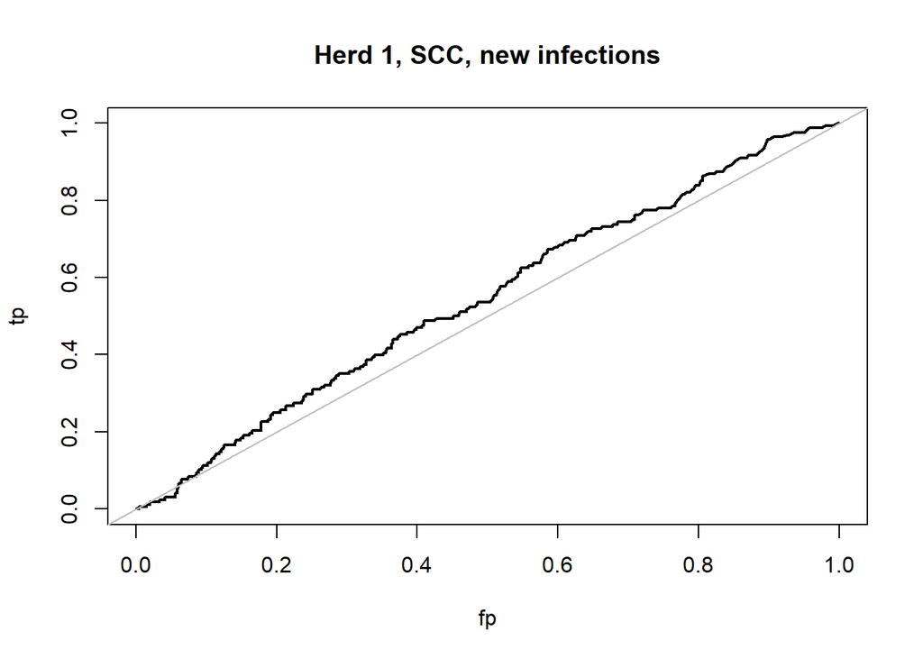

```r
library(pROC)

scc.upper <- 15000

#### Herd 1, New infections: ####
dt <- alldata[Herd==1]

# First we look at SCC:
fp <- rep(NA, scc.upper)
tp <- rep(NA, scc.upper)
#
for(scc.cut in 1:scc.upper) # thousands. So from 1,000 to 1,000,000.
{
  fp[scc.cut] <- 1 / length(dt$SCC[dt$newinf%in%0]) * length(dt$SCC[dt$SCC>=scc.cut & dt$newinf%in%0])
  tp[scc.cut] <- 1 / length(dt$SCC[dt$newinf%in%1]) * length(dt$SCC[dt$SCC>=scc.cut & dt$newinf%in%1])
}

par(mfrow=c(1,1))
plot(tp ~ fp, type="l", lwd=2, main="Herd 1, SCC, new infections")
abline(a=0, b=1, col="grey")
```

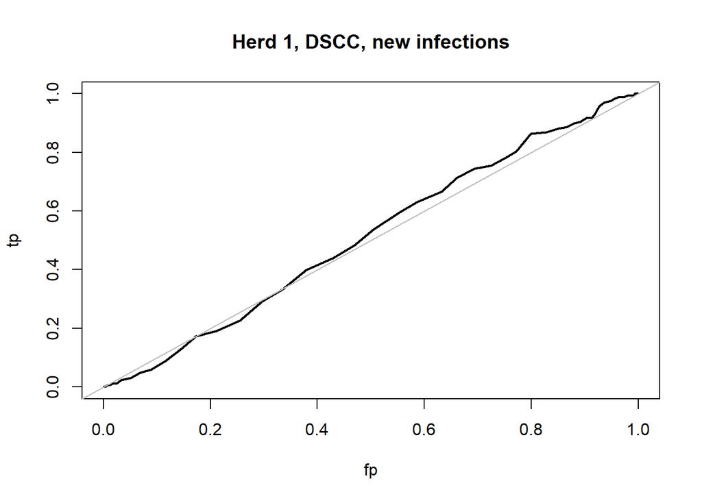

```r
# SCC is not that good.

tp.h1.scc.ni <- tp
fp.h1.scc.ni <- fp

# Then we look at DSCC:
fp <- rep(NA, 100)
tp <- rep(NA, 100)
#
for(dscc.cut in 1:100) # thousands. So from 1,000 to 1,000,000.
{
  fp[dscc.cut] <- 1 / length(dt$SCC[dt$newinf%in%0]) * length(dt$DSCC[dt$DSCC>=dscc.cut & dt$newinf%in%0])
  tp[dscc.cut] <- 1 / length(dt$SCC[dt$newinf%in%1]) * length(dt$DSCC[dt$DSCC>=dscc.cut & dt$newinf%in%1])
}

par(mfrow=c(1,1))
plot(tp ~ fp, type="l", lwd=2, main="Herd 1, DSCC, new infections")
abline(a=0, b=1, col="grey")
```

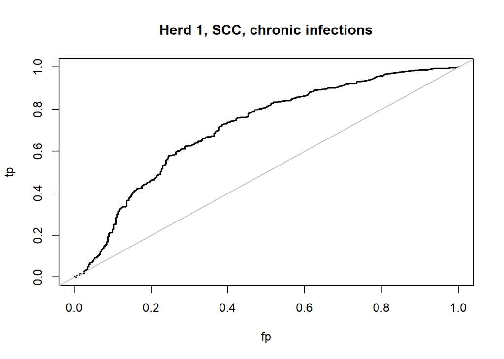

```r
# DSCC is not that good

tp.h1.dscc.ni <- tp
fp.h1.dscc.ni <- fp


#### Herd 1, Chronic infections: ####

# First we look at SCC:
fp <- rep(NA, scc.upper)
tp <- rep(NA, scc.upper)
#
for(scc.cut in 1:scc.upper) # thousands. So from 1,000 to 1,000,000.
{
  fp[scc.cut] <- 1 / length(dt$SCC[dt$chronic%in%0]) * length(dt$SCC[dt$SCC>=scc.cut & dt$chronic%in%0])
  tp[scc.cut] <- 1 / length(dt$SCC[dt$chronic%in%1]) * length(dt$SCC[dt$SCC>=scc.cut & dt$chronic%in%1])
}

par(mfrow=c(1,1))
plot(tp ~ fp, type="l", lwd=2, main="Herd 1, SCC, chronic infections")
abline(a=0, b=1, col="grey")
```

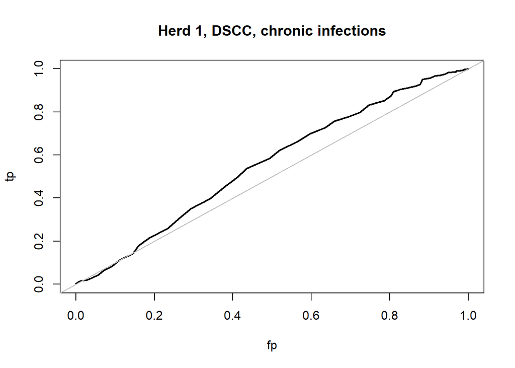

```r
# SCC is better for chronic infections.

tp.h1.scc.ch <- tp
fp.h1.scc.ch <- fp

# Then we look at DSCC:
fp <- rep(NA, 100)
tp <- rep(NA, 100)
#
for(dscc.cut in 1:100) # thousands. So from 1,000 to 1,000,000.
{
  fp[dscc.cut] <- 1 / length(dt$SCC[dt$chronic%in%0]) * length(dt$DSCC[dt$DSCC>=dscc.cut & dt$chronic%in%0])
  tp[dscc.cut] <- 1 / length(dt$SCC[dt$chronic%in%1]) * length(dt$DSCC[dt$DSCC>=dscc.cut & dt$chronic%in%1])
}

par(mfrow=c(1,1))
plot(tp ~ fp, type="l", lwd=2, main="Herd 1, DSCC, chronic infections")
abline(a=0, b=1, col="grey")
```

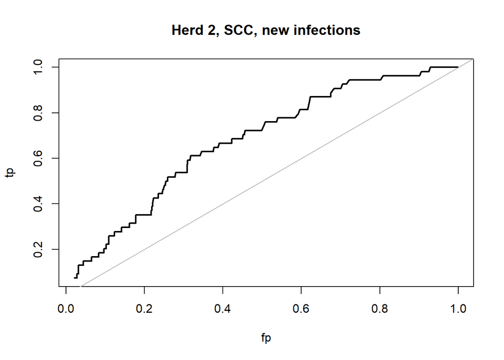

```r
# DSCC is not that good for chronic infections.

tp.h1.dscc.ch <- tp
fp.h1.dscc.ch <- fp




#### Herd 2, New infections: ####
dt <- alldata[Herd==2]

# First we look at SCC:
fp <- rep(NA, 1000)
tp <- rep(NA, 1000)
#
for(scc.cut in 1:1000) # thousands. So from 1,000 to 1,000,000.
{
  fp[scc.cut] <- 1 / length(dt$SCC[dt$newinf%in%0]) * length(dt$SCC[dt$SCC>=scc.cut & dt$newinf%in%0])
  tp[scc.cut] <- 1 / length(dt$SCC[dt$newinf%in%1]) * length(dt$SCC[dt$SCC>=scc.cut & dt$newinf%in%1])
}

par(mfrow=c(1,1))
plot(tp ~ fp, type="l", lwd=2, main="Herd 2, SCC, new infections")
abline(a=0, b=1, col="grey")
```

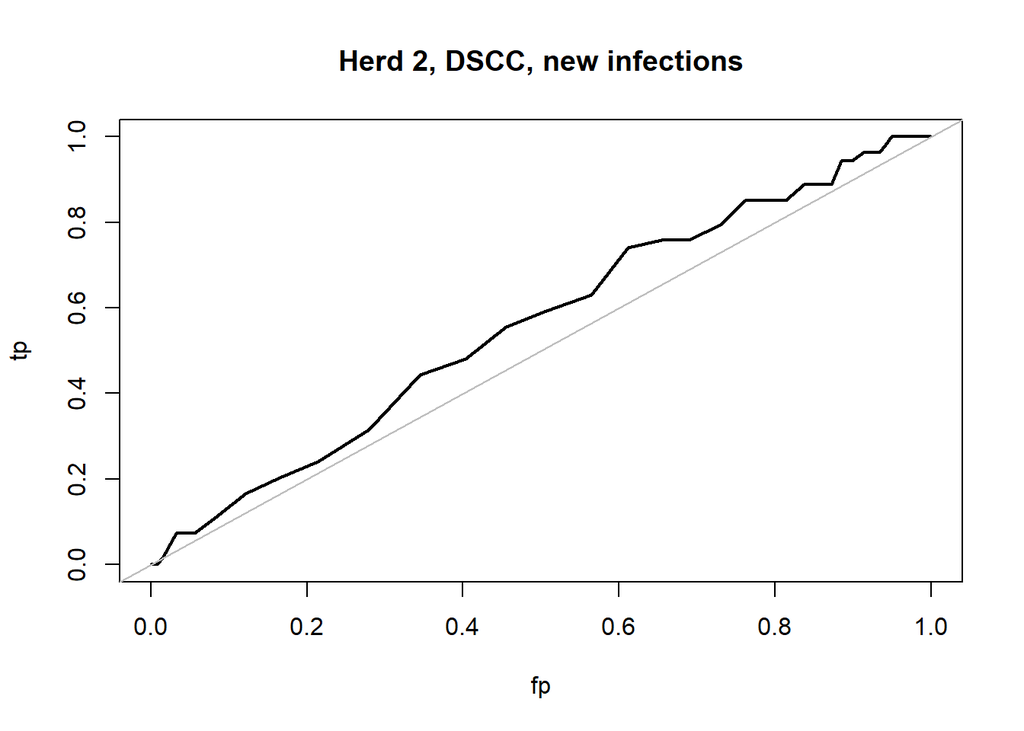

```r
# SCC is not that good, but better in Herd 2 than 1.

tp.h2.scc.ni <- tp
fp.h2.scc.ni <- fp

# Then we look at DSCC:
fp <- rep(NA, 100)
tp <- rep(NA, 100)
#
for(dscc.cut in 1:100) # thousands. So from 1,000 to 1,000,000.
{
  fp[dscc.cut] <- 1 / length(dt$SCC[dt$newinf%in%0]) * length(dt$DSCC[dt$DSCC>=dscc.cut & dt$newinf%in%0])
  tp[dscc.cut] <- 1 / length(dt$SCC[dt$newinf%in%1]) * length(dt$DSCC[dt$DSCC>=dscc.cut & dt$newinf%in%1])
}

par(mfrow=c(1,1))
plot(tp ~ fp, type="l", lwd=2, main="Herd 2, DSCC, new infections")
abline(a=0, b=1, col="grey")
```

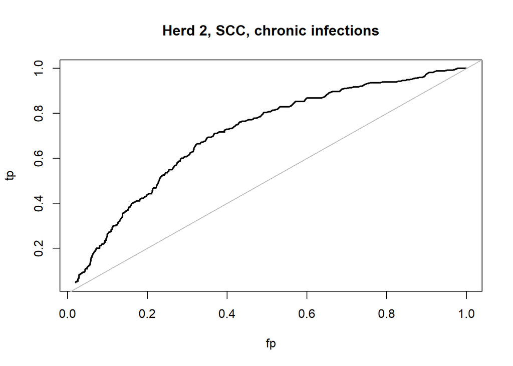

```r
# DSCC is not that good here either.

tp.h2.dscc.ni <- tp
fp.h2.dscc.ni <- fp

#### Herd 1, Chronic infections: ####

# First we look at SCC:
fp <- rep(NA, 1000)
tp <- rep(NA, 1000)
#
for(scc.cut in 1:1000) # thousands. So from 1,000 to 1,000,000.
{
  fp[scc.cut] <- 1 / length(dt$SCC[dt$chronic%in%0]) * length(dt$SCC[dt$SCC>=scc.cut & dt$chronic%in%0])
  tp[scc.cut] <- 1 / length(dt$SCC[dt$chronic%in%1]) * length(dt$SCC[dt$SCC>=scc.cut & dt$chronic%in%1])
}

par(mfrow=c(1,1))
plot(tp ~ fp, type="l", lwd=2, main="Herd 2, SCC, chronic infections")
abline(a=0, b=1, col="grey")
```

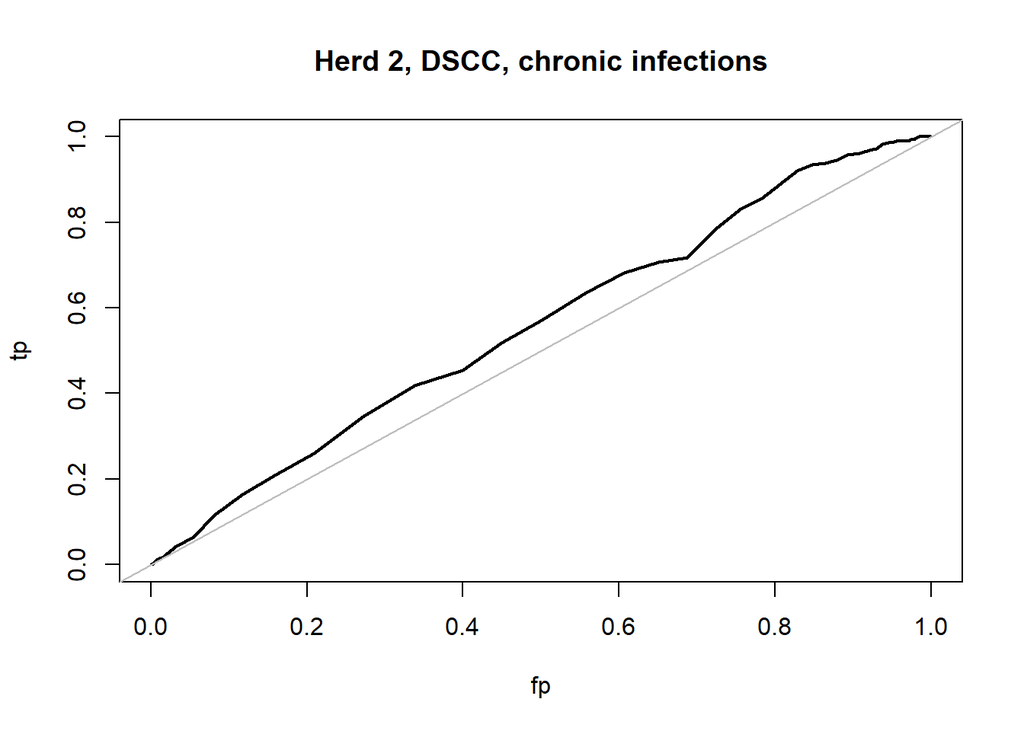

```r
# SCC is better for chronic infections.

tp.h2.scc.ch <- tp
fp.h2.scc.ch <- fp

# Then we look at DSCC:
fp <- rep(NA, 100)
tp <- rep(NA, 100)
#
for(dscc.cut in 1:100) # thousands. So from 1,000 to 1,000,000.
{
  fp[dscc.cut] <- 1 / length(dt$SCC[dt$chronic%in%0]) * length(dt$DSCC[dt$DSCC>=dscc.cut & dt$chronic%in%0])
  tp[dscc.cut] <- 1 / length(dt$SCC[dt$chronic%in%1]) * length(dt$DSCC[dt$DSCC>=dscc.cut & dt$chronic%in%1])
}

par(mfrow=c(1,1))
plot(tp ~ fp, type="l", lwd=2, main="Herd 2, DSCC, chronic infections")
abline(a=0, b=1, col="grey")
```

```r
# DSCC is not that good for chronic infections here either.

tp.h2.dscc.ch <- tp
fp.h2.dscc.ch <- fp
```

## Combined ROC

We can also look at a ROC curve for DSCC and SCC together. Here, both have to be above a threshold to indicate infection.

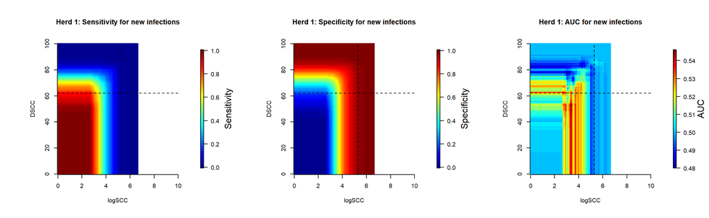

```r
#### Herd 1, New infections: ####
dt <- alldata[Herd==1]

# Prøver lige med logSCC i stedet:
dt$logSCC <- log(dt$SCC)
res <- as.data.frame(matrix(ncol=150, nrow=100))
res.se <- as.data.frame(matrix(ncol=150, nrow=100))
res.sp <- as.data.frame(matrix(ncol=150, nrow=100))
Start <- Sys.time()
logscc.er <- seq(0.01,10,0.1)
for(dscc.cut in 1:100)
{
  for(j in 1:100)
  {
    # We predict with scc and dscc:
    pred <- rep(0,length(dt$logSCC))
    pred[dt$logSCC>=logscc.er[j] & dt$DSCC>=dscc.cut] <- 1
    # And compare against the known category:
    categ <- dt$newinf
    roc_obj <- roc(categ, pred)
    res[dscc.cut,j] <- auc(roc_obj)
    # Se/Sp add-on:
    tmp <- as.data.frame(matrix(NA, nrow=2, ncol=2))
    colnames(tmp) <- c("TP", "TN")
    rownames(tmp) <- c("DSCC+", "DSCC-")
    tmp[1,1] <- sum(pred%in%1 & categ%in%1)
    tmp[1,2] <- sum(pred%in%1 & categ%in%0)
    tmp[2,1] <- sum(pred%in%0 & categ%in%1)
    tmp[2,2] <- sum(pred%in%0 & categ%in%0)
    res.se[dscc.cut,j] <- tmp[1,1] / sum(tmp[1,1],tmp[2,1])
    res.sp[dscc.cut,j] <- tmp[2,2] / sum(tmp[1,2],tmp[2,2])
  }
}
#Sys.time() - Start

#summary(unlist(res))

library(fields)

par(mfrow=c(1,3), ima=c(2,2,2,2), mar=c(6,8,6,8))
image.plot(z = as.matrix(t(res.se)), legend.lab = "Sensitivity", legend.line=3,
           ylab = "DSCC", xlab = "logSCC", main="Herd 1: Sensitivity for new infections", axes=F)
axis(2, at=seq(0,1,0.2), labels=paste(seq(0,100,20)))
axis(1, at=seq(0,1,0.2), labels=paste(seq(0,10,2)))
abline(v=(log(200)/10), lty=2)
abline(h=0.62, lty=2)
image.plot(z = as.matrix(t(res.sp)), legend.lab = "Specificity", legend.line=3,
           ylab = "DSCC", xlab = "logSCC", main="Herd 1: Specificity for new infections", axes=F)
axis(2, at=seq(0,1,0.2), labels=paste(seq(0,100,20)))
axis(1, at=seq(0,1,0.2), labels=paste(seq(0,10,2)))
abline(v=(log(200)/10), lty=2)
abline(h=0.62, lty=2)
image.plot(z = as.matrix(t(res)), legend.lab = "AUC", legend.line=3,
           ylab = "DSCC", xlab = "logSCC", main="Herd 1: AUC for new infections", axes=F)
axis(2, at=seq(0,1,0.2), labels=paste(seq(0,100,20)))
axis(1, at=seq(0,1,0.2), labels=paste(seq(0,10,2)))
abline(v=(log(200)/10), lty=2)
abline(h=0.62, lty=2)
```

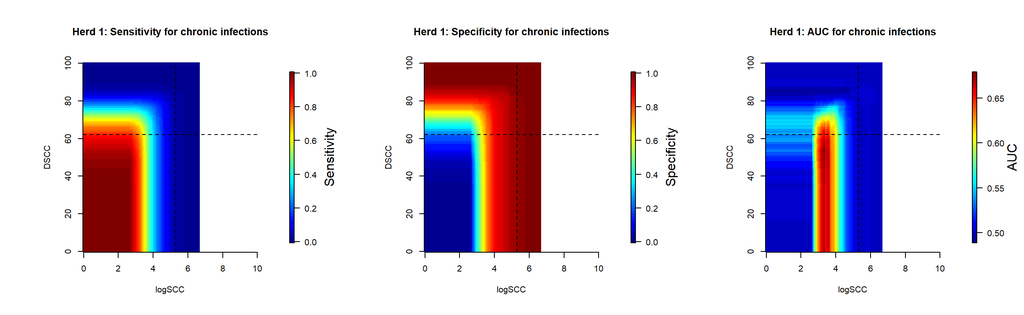

```r
#### Herd 1, New infections: ####
dt <- alldata[Herd==1]

# Prøver lige med logSCC i stedet:
dt$logSCC <- log(dt$SCC)
res <- as.data.frame(matrix(ncol=150, nrow=100))
Start <- Sys.time()
logscc.er <- seq(0.01,10,0.1)
for(dscc.cut in 1:100)
{
  for(j in 1:100)
  {
    # We predict with scc and dscc:
    pred <- rep(0,length(dt$logSCC))
    pred[dt$logSCC>=logscc.er[j] & dt$DSCC>=dscc.cut] <- 1
    # And compare against the known category:
    categ <- dt$chronic
    roc_obj <- roc(categ, pred)
    res[dscc.cut,j] <- auc(roc_obj)
    # Se/Sp add-on:
    tmp <- as.data.frame(matrix(NA, nrow=2, ncol=2))
    colnames(tmp) <- c("TP", "TN")
    rownames(tmp) <- c("DSCC+", "DSCC-")
    tmp[1,1] <- sum(pred%in%1 & categ%in%1)
    tmp[1,2] <- sum(pred%in%1 & categ%in%0)
    tmp[2,1] <- sum(pred%in%0 & categ%in%1)
    tmp[2,2] <- sum(pred%in%0 & categ%in%0)
    res.se[dscc.cut,j] <- tmp[1,1] / sum(tmp[1,1],tmp[2,1])
    res.sp[dscc.cut,j] <- tmp[2,2] / sum(tmp[1,2],tmp[2,2])
  }
}
#Sys.time() - Start
# Det tager <1 minut.

#summary(unlist(res))

library(fields)
par(mfrow=c(1,3), ima=c(2,2,2,2), mar=c(6,8,6,8))
image.plot(z = as.matrix(t(res.se)), legend.lab = "Sensitivity", legend.line=3,
           ylab = "DSCC", xlab = "logSCC", main="Herd 1: Sensitivity for chronic infections", axes=F)
axis(2, at=seq(0,1,0.2), labels=paste(seq(0,100,20)))
axis(1, at=seq(0,1,0.2), labels=paste(seq(0,10,2)))
abline(v=(log(200)/10), lty=2)
abline(h=0.62, lty=2)
image.plot(z = as.matrix(t(res.sp)), legend.lab = "Specificity", legend.line=3,
           ylab = "DSCC", xlab = "logSCC", main="Herd 1: Specificity for chronic infections", axes=F)
axis(2, at=seq(0,1,0.2), labels=paste(seq(0,100,20)))
axis(1, at=seq(0,1,0.2), labels=paste(seq(0,10,2)))
abline(v=(log(200)/10), lty=2)
abline(h=0.62, lty=2)
image.plot(z = as.matrix(t(res)), legend.lab = "AUC", legend.line=3,
           ylab = "DSCC", xlab = "logSCC", main="Herd 1: AUC for chronic infections", axes=F)
axis(2, at=seq(0,1,0.2), labels=paste(seq(0,100,20)))
axis(1, at=seq(0,1,0.2), labels=paste(seq(0,10,2)))
abline(v=(log(200)/10), lty=2)
abline(h=0.62, lty=2)
```

And Herd 2:

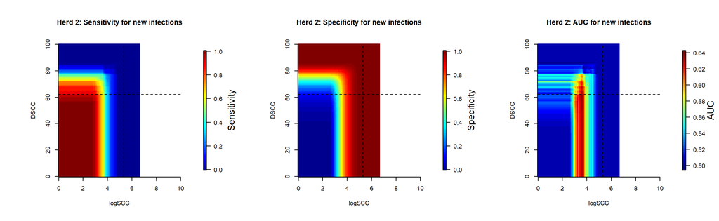

```r
#### Herd 1, New infections: ####
dt <- alldata[Herd==2]

# Prøver lige med logSCC i stedet:
dt$logSCC <- log(dt$SCC)
res <- as.data.frame(matrix(ncol=150, nrow=100))
Start <- Sys.time()
logscc.er <- seq(0.01,10,0.1)
for(dscc.cut in 1:100)
{
  for(j in 1:100)
  {
    # We predict with scc and dscc:
    pred <- rep(0,length(dt$logSCC))
    pred[dt$logSCC>=logscc.er[j] & dt$DSCC>=dscc.cut] <- 1
    # And compare against the known category:
    categ <- dt$newinf
    roc_obj <- roc(categ, pred)
    res[dscc.cut,j] <- auc(roc_obj)
    # Se/Sp add-on:
    tmp <- as.data.frame(matrix(NA, nrow=2, ncol=2))
    colnames(tmp) <- c("TP", "TN")
    rownames(tmp) <- c("DSCC+", "DSCC-")
    tmp[1,1] <- sum(pred%in%1 & categ%in%1)
    tmp[1,2] <- sum(pred%in%1 & categ%in%0)
    tmp[2,1] <- sum(pred%in%0 & categ%in%1)
    tmp[2,2] <- sum(pred%in%0 & categ%in%0)
    res.se[dscc.cut,j] <- tmp[1,1] / sum(tmp[1,1],tmp[2,1])
    res.sp[dscc.cut,j] <- tmp[2,2] / sum(tmp[1,2],tmp[2,2])
  }
}
#Sys.time() - Start
# Det tager <1 minut.

#summary(unlist(res))

library(fields)
par(mfrow=c(1,3), ima=c(2,2,2,2), mar=c(6,8,6,8))
image.plot(z = as.matrix(t(res.se)), legend.lab = "Sensitivity", legend.line=3,
           ylab = "DSCC", xlab = "logSCC", main="Herd 2: Sensitivity for new infections", axes=F)
axis(2, at=seq(0,1,0.2), labels=paste(seq(0,100,20)))
axis(1, at=seq(0,1,0.2), labels=paste(seq(0,10,2)))
abline(v=(log(200)/10), lty=2)
abline(h=0.62, lty=2)
image.plot(z = as.matrix(t(res.sp)), legend.lab = "Specificity", legend.line=3,
           ylab = "DSCC", xlab = "logSCC", main="Herd 2: Specificity for new infections", axes=F)
axis(2, at=seq(0,1,0.2), labels=paste(seq(0,100,20)))
axis(1, at=seq(0,1,0.2), labels=paste(seq(0,10,2)))
abline(v=(log(200)/10), lty=2)
abline(h=0.62, lty=2)
image.plot(z = as.matrix(t(res)), legend.lab = "AUC", legend.line=3,
           ylab = "DSCC", xlab = "logSCC", main="Herd 2: AUC for new infections", axes=F)
axis(2, at=seq(0,1,0.2), labels=paste(seq(0,100,20)))
axis(1, at=seq(0,1,0.2), labels=paste(seq(0,10,2)))
abline(v=(log(200)/10), lty=2)
abline(h=0.62, lty=2)
```

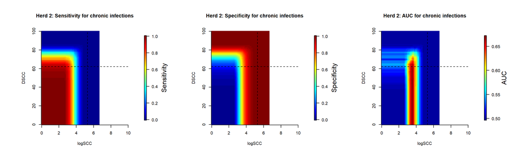

```r
#### Herd 1, New infections: ####
dt <- alldata[Herd==2]

# Prøver lige med logSCC i stedet:
dt$logSCC <- log(dt$SCC)
res <- as.data.frame(matrix(ncol=150, nrow=100))
Start <- Sys.time()
logscc.er <- seq(0.01,10,0.1)
for(dscc.cut in 1:100)
{
  for(j in 1:100)
  {
    # We predict with scc and dscc:
    pred <- rep(0,length(dt$logSCC))
    pred[dt$logSCC>=logscc.er[j] & dt$DSCC>=dscc.cut] <- 1
    # And compare against the known category:
    categ <- dt$chronic
    roc_obj <- roc(categ, pred)
    res[dscc.cut,j] <- auc(roc_obj)
    # Se/Sp add-on:
    tmp <- as.data.frame(matrix(NA, nrow=2, ncol=2))
    colnames(tmp) <- c("TP", "TN")
    rownames(tmp) <- c("DSCC+", "DSCC-")
    tmp[1,1] <- sum(pred%in%1 & categ%in%1)
    tmp[1,2] <- sum(pred%in%1 & categ%in%0)
    tmp[2,1] <- sum(pred%in%0 & categ%in%1)
    tmp[2,2] <- sum(pred%in%0 & categ%in%0)
    res.se[dscc.cut,j] <- tmp[1,1] / sum(tmp[1,1],tmp[2,1])
    res.sp[dscc.cut,j] <- tmp[2,2] / sum(tmp[1,2],tmp[2,2])
  }
}
#Sys.time() - Start
# Det tager <1 minut.

#summary(unlist(res))

library(fields)
par(mfrow=c(1,3), ima=c(2,2,2,2), mar=c(6,8,6,8))
image.plot(z = as.matrix(t(res.se)), legend.lab = "Sensitivity", legend.line=3,
           ylab = "DSCC", xlab = "logSCC", main="Herd 2: Sensitivity for chronic infections", axes=F)
axis(2, at=seq(0,1,0.2), labels=paste(seq(0,100,20)))
axis(1, at=seq(0,1,0.2), labels=paste(seq(0,10,2)))
abline(v=(log(200)/10), lty=2)
abline(h=0.62, lty=2)
image.plot(z = as.matrix(t(res.sp)), legend.lab = "Specificity", legend.line=3,
           ylab = "DSCC", xlab = "logSCC", main="Herd 2: Specificity for chronic infections", axes=F)
axis(2, at=seq(0,1,0.2), labels=paste(seq(0,100,20)))
axis(1, at=seq(0,1,0.2), labels=paste(seq(0,10,2)))
abline(v=(log(200)/10), lty=2)
abline(h=0.62, lty=2)
image.plot(z = as.matrix(t(res)), legend.lab = "AUC", legend.line=3,
           ylab = "DSCC", xlab = "logSCC", main="Herd 2: AUC for chronic infections", axes=F)
axis(2, at=seq(0,1,0.2), labels=paste(seq(0,100,20)))
axis(1, at=seq(0,1,0.2), labels=paste(seq(0,10,2)))
abline(v=(log(200)/10), lty=2)
abline(h=0.62, lty=2)
```

## Combined ROC Version 2

We here use the reverse threshold for DSCC so that DSCC should be below the DSCC threshold and SCC above the SCC threshold.

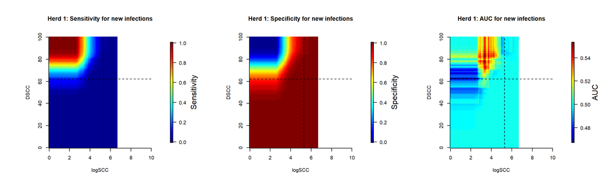

```r
#### Herd 1, New infections: ####
dt <- alldata[Herd==1]

# Prøver lige med logSCC i stedet:
dt$logSCC <- log(dt$SCC)
res <- as.data.frame(matrix(ncol=150, nrow=100))
Start <- Sys.time()
logscc.er <- seq(0.01,10,0.1)
for(dscc.cut in 1:100)
{
  for(j in 1:100)
  {
    # We predict with scc and dscc:
    pred <- rep(0,length(dt$logSCC))
    pred[dt$logSCC>=logscc.er[j] & dt$DSCC<=dscc.cut] <- 1
    # And compare against the known category:
    categ <- dt$newinf
    roc_obj <- roc(categ, pred)
    res[dscc.cut,j] <- auc(roc_obj)
    # Se/Sp add-on:
    tmp <- as.data.frame(matrix(NA, nrow=2, ncol=2))
    colnames(tmp) <- c("TP", "TN")
    rownames(tmp) <- c("DSCC+", "DSCC-")
    tmp[1,1] <- sum(pred%in%1 & categ%in%1)
    tmp[1,2] <- sum(pred%in%1 & categ%in%0)
    tmp[2,1] <- sum(pred%in%0 & categ%in%1)
    tmp[2,2] <- sum(pred%in%0 & categ%in%0)
    res.se[dscc.cut,j] <- tmp[1,1] / sum(tmp[1,1],tmp[2,1])
    res.sp[dscc.cut,j] <- tmp[2,2] / sum(tmp[1,2],tmp[2,2])
  }
}
#Sys.time() - Start
# Det tager <1 minut.

#summary(unlist(res))

library(fields)
par(mfrow=c(1,3), ima=c(2,2,2,2), mar=c(6,8,6,8))
image.plot(z = as.matrix(t(res.se)), legend.lab = "Sensitivity", legend.line=3,
           ylab = "DSCC", xlab = "logSCC", main="Herd 1: Sensitivity for new infections", axes=F)
axis(2, at=seq(0,1,0.2), labels=paste(seq(0,100,20)))
axis(1, at=seq(0,1,0.2), labels=paste(seq(0,10,2)))
abline(v=(log(200)/10), lty=2)
abline(h=0.62, lty=2)
image.plot(z = as.matrix(t(res.sp)), legend.lab = "Specificity", legend.line=3,
           ylab = "DSCC", xlab = "logSCC", main="Herd 1: Specificity for new infections", axes=F)
axis(2, at=seq(0,1,0.2), labels=paste(seq(0,100,20)))
axis(1, at=seq(0,1,0.2), labels=paste(seq(0,10,2)))
abline(v=(log(200)/10), lty=2)
abline(h=0.62, lty=2)
image.plot(z = as.matrix(t(res)), legend.lab = "AUC", legend.line=3,
           ylab = "DSCC", xlab = "logSCC", main="Herd 1: AUC for new infections", axes=F)
axis(2, at=seq(0,1,0.2), labels=paste(seq(0,100,20)))
axis(1, at=seq(0,1,0.2), labels=paste(seq(0,10,2)))
abline(v=(log(200)/10), lty=2)
abline(h=0.62, lty=2)
```

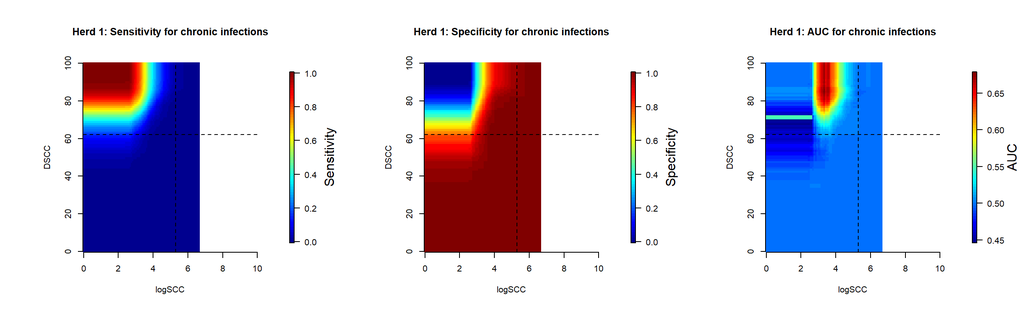

```r
#### Herd 1, New infections: ####
dt <- alldata[Herd==1]

# Prøver lige med logSCC i stedet:
dt$logSCC <- log(dt$SCC)
res <- as.data.frame(matrix(ncol=150, nrow=100))
Start <- Sys.time()
logscc.er <- seq(0.01,10,0.1)
for(dscc.cut in 1:100)
{
  for(j in 1:100)
  {
    # We predict with scc and dscc:
    pred <- rep(0,length(dt$logSCC))
    pred[dt$logSCC>=logscc.er[j] & dt$DSCC<=dscc.cut] <- 1
    # And compare against the known category:
    categ <- dt$chronic
    roc_obj <- roc(categ, pred)
    res[dscc.cut,j] <- auc(roc_obj)
    # Se/Sp add-on:
    tmp <- as.data.frame(matrix(NA, nrow=2, ncol=2))
    colnames(tmp) <- c("TP", "TN")
    rownames(tmp) <- c("DSCC+", "DSCC-")
    tmp[1,1] <- sum(pred%in%1 & categ%in%1)
    tmp[1,2] <- sum(pred%in%1 & categ%in%0)
    tmp[2,1] <- sum(pred%in%0 & categ%in%1)
    tmp[2,2] <- sum(pred%in%0 & categ%in%0)
    res.se[dscc.cut,j] <- tmp[1,1] / sum(tmp[1,1],tmp[2,1])
    res.sp[dscc.cut,j] <- tmp[2,2] / sum(tmp[1,2],tmp[2,2])
  }
}
#Sys.time() - Start
# Det tager <1 minut.

#summary(unlist(res))

library(fields)
par(mfrow=c(1,3), ima=c(2,2,2,2), mar=c(6,8,6,8))
image.plot(z = as.matrix(t(res.se)), legend.lab = "Sensitivity", legend.line=3,
           ylab = "DSCC", xlab = "logSCC", main="Herd 1: Sensitivity for chronic infections", axes=F)
axis(2, at=seq(0,1,0.2), labels=paste(seq(0,100,20)))
axis(1, at=seq(0,1,0.2), labels=paste(seq(0,10,2)))
abline(v=(log(200)/10), lty=2)
abline(h=0.62, lty=2)
image.plot(z = as.matrix(t(res.sp)), legend.lab = "Specificity", legend.line=3,
           ylab = "DSCC", xlab = "logSCC", main="Herd 1: Specificity for chronic infections", axes=F)
axis(2, at=seq(0,1,0.2), labels=paste(seq(0,100,20)))
axis(1, at=seq(0,1,0.2), labels=paste(seq(0,10,2)))
abline(v=(log(200)/10), lty=2)
abline(h=0.62, lty=2)
image.plot(z = as.matrix(t(res)), legend.lab = "AUC", legend.line=3,
           ylab = "DSCC", xlab = "logSCC", main="Herd 1: AUC for chronic infections", axes=F)
axis(2, at=seq(0,1,0.2), labels=paste(seq(0,100,20)))
axis(1, at=seq(0,1,0.2), labels=paste(seq(0,10,2)))
abline(v=(log(200)/10), lty=2)
abline(h=0.62, lty=2)
```

And Herd 2:

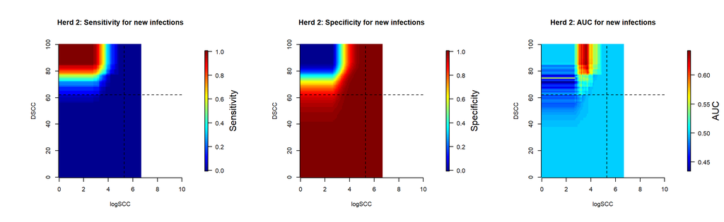

```r
#### Herd 1, New infections: ####
dt <- alldata[Herd==2]

# Prøver lige med logSCC i stedet:
dt$logSCC <- log(dt$SCC)
res <- as.data.frame(matrix(ncol=150, nrow=100))
Start <- Sys.time()
logscc.er <- seq(0.01,10,0.1)
for(dscc.cut in 1:100)
{
  for(j in 1:100)
  {
    # We predict with scc and dscc:
    pred <- rep(0,length(dt$logSCC))
    pred[dt$logSCC>=logscc.er[j] & dt$DSCC<=dscc.cut] <- 1
    # And compare against the known category:
    categ <- dt$newinf
    roc_obj <- roc(categ, pred)
    res[dscc.cut,j] <- auc(roc_obj)
    # Se/Sp add-on:
    tmp <- as.data.frame(matrix(NA, nrow=2, ncol=2))
    colnames(tmp) <- c("TP", "TN")
    rownames(tmp) <- c("DSCC+", "DSCC-")
    tmp[1,1] <- sum(pred%in%1 & categ%in%1)
    tmp[1,2] <- sum(pred%in%1 & categ%in%0)
    tmp[2,1] <- sum(pred%in%0 & categ%in%1)
    tmp[2,2] <- sum(pred%in%0 & categ%in%0)
    res.se[dscc.cut,j] <- tmp[1,1] / sum(tmp[1,1],tmp[2,1])
    res.sp[dscc.cut,j] <- tmp[2,2] / sum(tmp[1,2],tmp[2,2])
  }
}
#Sys.time() - Start
# Det tager <1 minut.

#summary(unlist(res))

library(fields)
par(mfrow=c(1,3), ima=c(2,2,2,2), mar=c(6,8,6,8))
image.plot(z = as.matrix(t(res.se)), legend.lab = "Sensitivity", legend.line=3,
           ylab = "DSCC", xlab = "logSCC", main="Herd 2: Sensitivity for new infections", axes=F)
axis(2, at=seq(0,1,0.2), labels=paste(seq(0,100,20)))
axis(1, at=seq(0,1,0.2), labels=paste(seq(0,10,2)))
abline(v=(log(200)/10), lty=2)
abline(h=0.62, lty=2)
image.plot(z = as.matrix(t(res.sp)), legend.lab = "Specificity", legend.line=3,
           ylab = "DSCC", xlab = "logSCC", main="Herd 2: Specificity for new infections", axes=F)
axis(2, at=seq(0,1,0.2), labels=paste(seq(0,100,20)))
axis(1, at=seq(0,1,0.2), labels=paste(seq(0,10,2)))
abline(v=(log(200)/10), lty=2)
abline(h=0.62, lty=2)
image.plot(z = as.matrix(t(res)), legend.lab = "AUC", legend.line=3,
           ylab = "DSCC", xlab = "logSCC", main="Herd 2: AUC for new infections", axes=F)
axis(2, at=seq(0,1,0.2), labels=paste(seq(0,100,20)))
axis(1, at=seq(0,1,0.2), labels=paste(seq(0,10,2)))
abline(v=(log(200)/10), lty=2)
abline(h=0.62, lty=2)
```

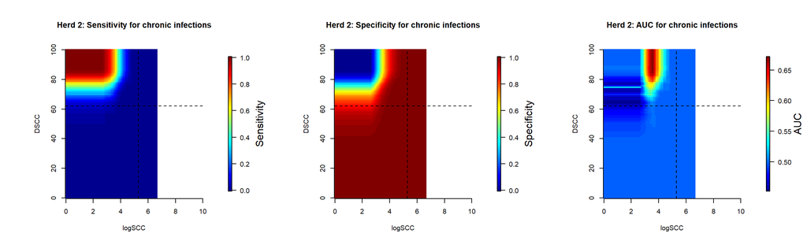

```r
#### Herd 1, New infections: ####
dt <- alldata[Herd==2]

# Prøver lige med logSCC i stedet:
dt$logSCC <- log(dt$SCC)
res <- as.data.frame(matrix(ncol=150, nrow=100))
Start <- Sys.time()
logscc.er <- seq(0.01,10,0.1)
for(dscc.cut in 1:100)
{
  for(j in 1:100)
  {
    # We predict with scc and dscc:
    pred <- rep(0,length(dt$logSCC))
    pred[dt$logSCC>=logscc.er[j] & dt$DSCC<=dscc.cut] <- 1
    # And compare against the known category:
    categ <- dt$chronic
    roc_obj <- roc(categ, pred)
    res[dscc.cut,j] <- auc(roc_obj)
    # Se/Sp add-on:
    tmp <- as.data.frame(matrix(NA, nrow=2, ncol=2))
    colnames(tmp) <- c("TP", "TN")
    rownames(tmp) <- c("DSCC+", "DSCC-")
    tmp[1,1] <- sum(pred%in%1 & categ%in%1)
    tmp[1,2] <- sum(pred%in%1 & categ%in%0)
    tmp[2,1] <- sum(pred%in%0 & categ%in%1)
    tmp[2,2] <- sum(pred%in%0 & categ%in%0)
    res.se[dscc.cut,j] <- tmp[1,1] / sum(tmp[1,1],tmp[2,1])
    res.sp[dscc.cut,j] <- tmp[2,2] / sum(tmp[1,2],tmp[2,2])
  }
}
#Sys.time() - Start
# Det tager <1 minut.

#summary(unlist(res))

library(fields)
par(mfrow=c(1,3), ima=c(2,2,2,2), mar=c(6,8,6,8))
image.plot(z = as.matrix(t(res.se)), legend.lab = "Sensitivity", legend.line=3,
           ylab = "DSCC", xlab = "logSCC", main="Herd 2: Sensitivity for chronic infections", axes=F)
axis(2, at=seq(0,1,0.2), labels=paste(seq(0,100,20)))
axis(1, at=seq(0,1,0.2), labels=paste(seq(0,10,2)))
abline(v=(log(200)/10), lty=2)
abline(h=0.62, lty=2)
image.plot(z = as.matrix(t(res.sp)), legend.lab = "Specificity", legend.line=3,
           ylab = "DSCC", xlab = "logSCC", main="Herd 2: Specificity for chronic infections", axes=F)
axis(2, at=seq(0,1,0.2), labels=paste(seq(0,100,20)))
axis(1, at=seq(0,1,0.2), labels=paste(seq(0,10,2)))
abline(v=(log(200)/10), lty=2)
abline(h=0.62, lty=2)
image.plot(z = as.matrix(t(res)), legend.lab = "AUC", legend.line=3,
           ylab = "DSCC", xlab = "logSCC", main="Herd 2: AUC for chronic infections", axes=F)
axis(2, at=seq(0,1,0.2), labels=paste(seq(0,100,20)))
axis(1, at=seq(0,1,0.2), labels=paste(seq(0,10,2)))
abline(v=(log(200)/10), lty=2)
abline(h=0.62, lty=2)
```

## Combined ROC Version 3

We here use the reverse threshold for SCC so that SCC should be below the SCC threshold and DSCC above the DSCC threshold.

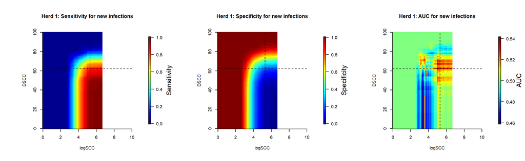

```r
#### Herd 1, New infections: ####
dt <- alldata[Herd==1]

# Prøver lige med logSCC i stedet:
dt$logSCC <- log(dt$SCC)
res <- as.data.frame(matrix(ncol=150, nrow=100))
Start <- Sys.time()
logscc.er <- seq(0.01,10,0.1)
for(dscc.cut in 1:100)
{
  for(j in 1:100)
  {
    # We predict with scc and dscc:
    pred <- rep(0,length(dt$logSCC))
    pred[dt$logSCC<=logscc.er[j] & dt$DSCC>=dscc.cut] <- 1
    # And compare against the known category:
    categ <- dt$newinf
    roc_obj <- roc(categ, pred)
    res[dscc.cut,j] <- auc(roc_obj)
    # Se/Sp add-on:
    tmp <- as.data.frame(matrix(NA, nrow=2, ncol=2))
    colnames(tmp) <- c("TP", "TN")
    rownames(tmp) <- c("DSCC+", "DSCC-")
    tmp[1,1] <- sum(pred%in%1 & categ%in%1)
    tmp[1,2] <- sum(pred%in%1 & categ%in%0)
    tmp[2,1] <- sum(pred%in%0 & categ%in%1)
    tmp[2,2] <- sum(pred%in%0 & categ%in%0)
    res.se[dscc.cut,j] <- tmp[1,1] / sum(tmp[1,1],tmp[2,1])
    res.sp[dscc.cut,j] <- tmp[2,2] / sum(tmp[1,2],tmp[2,2])
  }
}
#Sys.time() - Start
# Det tager <1 minut.

#summary(unlist(res))

library(fields)
par(mfrow=c(1,3), ima=c(2,2,2,2), mar=c(6,8,6,8))
image.plot(z = as.matrix(t(res.se)), legend.lab = "Sensitivity", legend.line=3,
           ylab = "DSCC", xlab = "logSCC", main="Herd 1: Sensitivity for new infections", axes=F)
axis(2, at=seq(0,1,0.2), labels=paste(seq(0,100,20)))
axis(1, at=seq(0,1,0.2), labels=paste(seq(0,10,2)))
abline(v=(log(200)/10), lty=2)
abline(h=0.62, lty=2)
image.plot(z = as.matrix(t(res.sp)), legend.lab = "Specificity", legend.line=3,
           ylab = "DSCC", xlab = "logSCC", main="Herd 1: Specificity for new infections", axes=F)
axis(2, at=seq(0,1,0.2), labels=paste(seq(0,100,20)))
axis(1, at=seq(0,1,0.2), labels=paste(seq(0,10,2)))
abline(v=(log(200)/10), lty=2)
abline(h=0.62, lty=2)
image.plot(z = as.matrix(t(res)), legend.lab = "AUC", legend.line=3,
           ylab = "DSCC", xlab = "logSCC", main="Herd 1: AUC for new infections", axes=F)
axis(2, at=seq(0,1,0.2), labels=paste(seq(0,100,20)))
axis(1, at=seq(0,1,0.2), labels=paste(seq(0,10,2)))
abline(v=(log(200)/10), lty=2)
abline(h=0.62, lty=2)
```

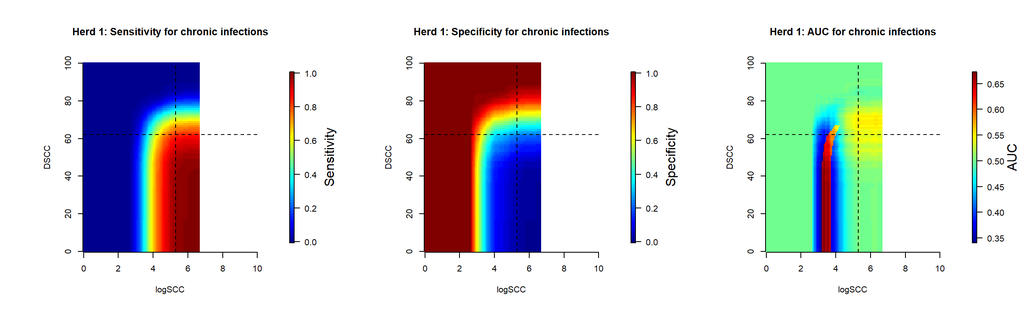

```r
#### Herd 1, New infections: ####
dt <- alldata[Herd==1]

# Prøver lige med logSCC i stedet:
dt$logSCC <- log(dt$SCC)
res <- as.data.frame(matrix(ncol=150, nrow=100))
Start <- Sys.time()
logscc.er <- seq(0.01,10,0.1)
for(dscc.cut in 1:100)
{
  for(j in 1:100)
  {
    # We predict with scc and dscc:
    pred <- rep(0,length(dt$logSCC))
    pred[dt$logSCC<=logscc.er[j] & dt$DSCC>=dscc.cut] <- 1
    # And compare against the known category:
    categ <- dt$chronic
    roc_obj <- roc(categ, pred)
    res[dscc.cut,j] <- auc(roc_obj)
    # Se/Sp add-on:
    tmp <- as.data.frame(matrix(NA, nrow=2, ncol=2))
    colnames(tmp) <- c("TP", "TN")
    rownames(tmp) <- c("DSCC+", "DSCC-")
    tmp[1,1] <- sum(pred%in%1 & categ%in%1)
    tmp[1,2] <- sum(pred%in%1 & categ%in%0)
    tmp[2,1] <- sum(pred%in%0 & categ%in%1)
    tmp[2,2] <- sum(pred%in%0 & categ%in%0)
    res.se[dscc.cut,j] <- tmp[1,1] / sum(tmp[1,1],tmp[2,1])
    res.sp[dscc.cut,j] <- tmp[2,2] / sum(tmp[1,2],tmp[2,2])
  }
}
#Sys.time() - Start
# Det tager <1 minut.

#summary(unlist(res))

library(fields)
par(mfrow=c(1,3), ima=c(2,2,2,2), mar=c(6,8,6,8))
image.plot(z = as.matrix(t(res.se)), legend.lab = "Sensitivity", legend.line=3,
           ylab = "DSCC", xlab = "logSCC", main="Herd 1: Sensitivity for chronic infections", axes=F)
axis(2, at=seq(0,1,0.2), labels=paste(seq(0,100,20)))
axis(1, at=seq(0,1,0.2), labels=paste(seq(0,10,2)))
abline(v=(log(200)/10), lty=2)
abline(h=0.62, lty=2)
image.plot(z = as.matrix(t(res.sp)), legend.lab = "Specificity", legend.line=3,
           ylab = "DSCC", xlab = "logSCC", main="Herd 1: Specificity for chronic infections", axes=F)
axis(2, at=seq(0,1,0.2), labels=paste(seq(0,100,20)))
axis(1, at=seq(0,1,0.2), labels=paste(seq(0,10,2)))
abline(v=(log(200)/10), lty=2)
abline(h=0.62, lty=2)
image.plot(z = as.matrix(t(res)), legend.lab = "AUC", legend.line=3,
           ylab = "DSCC", xlab = "logSCC", main="Herd 1: AUC for chronic infections", axes=F)
axis(2, at=seq(0,1,0.2), labels=paste(seq(0,100,20)))
axis(1, at=seq(0,1,0.2), labels=paste(seq(0,10,2)))
abline(v=(log(200)/10), lty=2)
abline(h=0.62, lty=2)
```

And Herd 2:

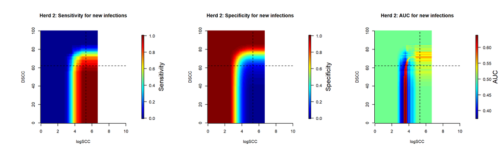

```r
#### Herd 1, New infections: ####
dt <- alldata[Herd==2]

# Prøver lige med logSCC i stedet:
dt$logSCC <- log(dt$SCC)
res <- as.data.frame(matrix(ncol=150, nrow=100))
Start <- Sys.time()
logscc.er <- seq(0.01,10,0.1)
for(dscc.cut in 1:100)
{
  for(j in 1:100)
  {
    # We predict with scc and dscc:
    pred <- rep(0,length(dt$logSCC))
    pred[dt$logSCC<=logscc.er[j] & dt$DSCC>=dscc.cut] <- 1
    # And compare against the known category:
    categ <- dt$newinf
    roc_obj <- roc(categ, pred)
    res[dscc.cut,j] <- auc(roc_obj)
    # Se/Sp add-on:
    tmp <- as.data.frame(matrix(NA, nrow=2, ncol=2))
    colnames(tmp) <- c("TP", "TN")
    rownames(tmp) <- c("DSCC+", "DSCC-")
    tmp[1,1] <- sum(pred%in%1 & categ%in%1)
    tmp[1,2] <- sum(pred%in%1 & categ%in%0)
    tmp[2,1] <- sum(pred%in%0 & categ%in%1)
    tmp[2,2] <- sum(pred%in%0 & categ%in%0)
    res.se[dscc.cut,j] <- tmp[1,1] / sum(tmp[1,1],tmp[2,1])
    res.sp[dscc.cut,j] <- tmp[2,2] / sum(tmp[1,2],tmp[2,2])
  }
}
#Sys.time() - Start
# Det tager <1 minut.

#summary(unlist(res))

library(fields)
par(mfrow=c(1,3), ima=c(2,2,2,2), mar=c(6,8,6,8))
image.plot(z = as.matrix(t(res.se)), legend.lab = "Sensitivity", legend.line=3,
           ylab = "DSCC", xlab = "logSCC", main="Herd 2: Sensitivity for new infections", axes=F)
axis(2, at=seq(0,1,0.2), labels=paste(seq(0,100,20)))
axis(1, at=seq(0,1,0.2), labels=paste(seq(0,10,2)))
abline(v=(log(200)/10), lty=2)
abline(h=0.62, lty=2)
image.plot(z = as.matrix(t(res.sp)), legend.lab = "Specificity", legend.line=3,
           ylab = "DSCC", xlab = "logSCC", main="Herd 2: Specificity for new infections", axes=F)
axis(2, at=seq(0,1,0.2), labels=paste(seq(0,100,20)))
axis(1, at=seq(0,1,0.2), labels=paste(seq(0,10,2)))
abline(v=(log(200)/10), lty=2)
abline(h=0.62, lty=2)
image.plot(z = as.matrix(t(res)), legend.lab = "AUC", legend.line=3,
           ylab = "DSCC", xlab = "logSCC", main="Herd 2: AUC for new infections", axes=F)
axis(2, at=seq(0,1,0.2), labels=paste(seq(0,100,20)))
axis(1, at=seq(0,1,0.2), labels=paste(seq(0,10,2)))
abline(v=(log(200)/10), lty=2)
abline(h=0.62, lty=2)
```

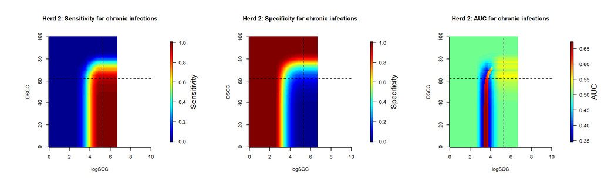

```r
#### Herd 1, New infections: ####
dt <- alldata[Herd==2]

# Prøver lige med logSCC i stedet:
dt$logSCC <- log(dt$SCC)
res <- as.data.frame(matrix(ncol=150, nrow=100))
Start <- Sys.time()
logscc.er <- seq(0.01,10,0.1)
for(dscc.cut in 1:100)
{
  for(j in 1:100)
  {
    # We predict with scc and dscc:
    pred <- rep(0,length(dt$logSCC))
    pred[dt$logSCC<=logscc.er[j] & dt$DSCC>=dscc.cut] <- 1
    # And compare against the known category:
    categ <- dt$chronic
    roc_obj <- roc(categ, pred)
    res[dscc.cut,j] <- auc(roc_obj)
    # Se/Sp add-on:
    tmp <- as.data.frame(matrix(NA, nrow=2, ncol=2))
    colnames(tmp) <- c("TP", "TN")
    rownames(tmp) <- c("DSCC+", "DSCC-")
    tmp[1,1] <- sum(pred%in%1 & categ%in%1)
    tmp[1,2] <- sum(pred%in%1 & categ%in%0)
    tmp[2,1] <- sum(pred%in%0 & categ%in%1)
    tmp[2,2] <- sum(pred%in%0 & categ%in%0)
    res.se[dscc.cut,j] <- tmp[1,1] / sum(tmp[1,1],tmp[2,1])
    res.sp[dscc.cut,j] <- tmp[2,2] / sum(tmp[1,2],tmp[2,2])
  }
}
#Sys.time() - Start
# Det tager <1 minut.

#summary(unlist(res))

library(fields)
par(mfrow=c(1,3), ima=c(2,2,2,2), mar=c(6,8,6,8))
image.plot(z = as.matrix(t(res.se)), legend.lab = "Sensitivity", legend.line=3,
           ylab = "DSCC", xlab = "logSCC", main="Herd 2: Sensitivity for chronic infections", axes=F)
axis(2, at=seq(0,1,0.2), labels=paste(seq(0,100,20)))
axis(1, at=seq(0,1,0.2), labels=paste(seq(0,10,2)))
abline(v=(log(200)/10), lty=2)
abline(h=0.62, lty=2)
image.plot(z = as.matrix(t(res.sp)), legend.lab = "Specificity", legend.line=3,
           ylab = "DSCC", xlab = "logSCC", main="Herd 2: Specificity for chronic infections", axes=F)
axis(2, at=seq(0,1,0.2), labels=paste(seq(0,100,20)))
axis(1, at=seq(0,1,0.2), labels=paste(seq(0,10,2)))
abline(v=(log(200)/10), lty=2)
abline(h=0.62, lty=2)
image.plot(z = as.matrix(t(res)), legend.lab = "AUC", legend.line=3,
           ylab = "DSCC", xlab = "logSCC", main="Herd 2: AUC for chronic infections", axes=F)
axis(2, at=seq(0,1,0.2), labels=paste(seq(0,100,20)))
axis(1, at=seq(0,1,0.2), labels=paste(seq(0,10,2)))
abline(v=(log(200)/10), lty=2)
abline(h=0.62, lty=2)
```

## Combined ROC Version 4

We here use the relationship between previous scc and previous dscc and look at the change in percent. Here, scc is below the scc pct change (x-axis) and dscc is above the dscc pct change (y-axis).

New infections, Herd 1:

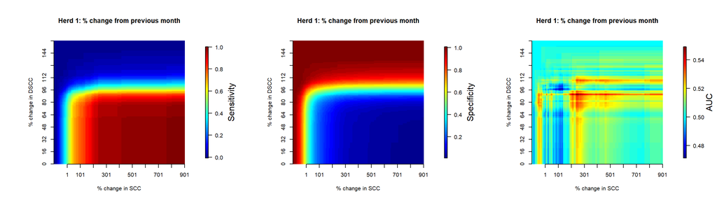

```r
#zave.image("P:/Mastitis/EMCoMast/EMCoMAST_data/DCC_data/DCC_2/savebeforecombinedv3.Rdata")

#### Herd 1, New infections: ####
dt <- alldata[Herd==1]

dt <- dt[!is.na(dt$dscc.prev)]
dt <- dt[!is.na(dt$scc.prev)]
# Calculate percentwise change:
dt$scc.pct.change <- NA
dt$dscc.pct.change <- NA
dt$scc.pct.change[!is.na(dt$scc.prev)] <- 100/dt$scc.prev[!is.na(dt$scc.prev)] * dt$SCC[!is.na(dt$scc.prev)]
dt$dscc.pct.change <- 100/dt$dscc.prev * dt$DSCC
#
pct.scc <- seq(1,1000,5)
res <- as.data.frame(matrix(ncol=length(pct.scc), nrow=160))
res.se <- as.data.frame(matrix(ncol=length(pct.scc), nrow=160))
res.sp <- as.data.frame(matrix(ncol=length(pct.scc), nrow=160))
for(pct.dscc in 1:160)
{
  for(j in 1:200)
  {
    # We predict with scc and dscc:
    pred <- rep(0,length(dt$SCC))
    pred[dt$scc.pct.change <= pct.scc[j] & dt$dscc.pct.change >= pct.dscc] <- 1
    # And compare against the known category:
    categ <- dt$newinf
    roc_obj <- roc(categ, pred)
    res[pct.dscc,j] <- auc(roc_obj)
    # Se/Sp add-on:
    tmp <- as.data.frame(matrix(NA, nrow=2, ncol=2))
    colnames(tmp) <- c("TP", "TN")
    rownames(tmp) <- c("DSCC+", "DSCC-")
    tmp[1,1] <- sum(pred%in%1 & categ%in%1)
    tmp[1,2] <- sum(pred%in%1 & categ%in%0)
    tmp[2,1] <- sum(pred%in%0 & categ%in%1)
    tmp[2,2] <- sum(pred%in%0 & categ%in%0)
    res.se[pct.dscc,j] <- tmp[1,1] / sum(tmp[1,1],tmp[2,1])
    res.sp[pct.dscc,j] <- tmp[2,2] / sum(tmp[1,2],tmp[2,2])
  }
}

#summary(unlist(res))

library(fields)
par(mfrow=c(1,3), ima=c(2,2,2,2), mar=c(6,8,6,8))
image.plot(z = as.matrix(t(res.se)), legend.lab = "Sensitivity", legend.line=3,
           ylab = "% change in DSCC", xlab = "% change in SCC", main="Herd 1: % change from previous month", axes=FALSE)
axis(2, at=seq(0,1,0.1), labels=paste(seq(0,160,16)))
axis(1, at=seq(0.1,1,0.1), labels=paste(pct.scc[seq(1,length(pct.scc),20)]))
image.plot(z = as.matrix(t(res.sp)), legend.lab = "Specificity", legend.line=3,
           ylab = "% change in DSCC", xlab = "% change in SCC", main="Herd 1: % change from previous month", axes=FALSE)
axis(2, at=seq(0,1,0.1), labels=paste(seq(0,160,16)))
axis(1, at=seq(0.1,1,0.1), labels=paste(pct.scc[seq(1,length(pct.scc),20)]))
image.plot(z = as.matrix(t(res)), legend.lab = "AUC", legend.line=3,
           ylab = "% change in DSCC", xlab = "% change in SCC", main="Herd 1: % change from previous month", axes=FALSE)
axis(2, at=seq(0,1,0.1), labels=paste(seq(0,160,16)))
axis(1, at=seq(0.1,1,0.1), labels=paste(pct.scc[seq(1,length(pct.scc),20)]))
```

Chronic infections, Herd 1:

```r
#### Herd 1, New infections: ####
dt <- alldata[Herd==1]

dt <- dt[!is.na(dt$dscc.prev)]
dt <- dt[!is.na(dt$scc.prev)]
# Calculate percentwise change:
dt$scc.pct.change <- NA
dt$dscc.pct.change <- NA
dt$scc.pct.change[!is.na(dt$scc.prev)] <- 100/dt$scc.prev[!is.na(dt$scc.prev)] * dt$SCC[!is.na(dt$scc.prev)]
dt$dscc.pct.change <- 100/dt$dscc.prev * dt$DSCC

# Calculate percentwise change:
dt$scc.pct.change <- 100/dt$scc.prev * dt$SCC
dt$dscc.pct.change <- 100/dt$dscc.prev * dt$DSCC

# Prøver lige med logSCC i stedet:
pct.scc <- seq(1,1000,5)
res <- as.data.frame(matrix(ncol=length(pct.scc), nrow=160))
res.se <- as.data.frame(matrix(ncol=length(pct.scc), nrow=160))
res.sp <- as.data.frame(matrix(ncol=length(pct.scc), nrow=160))
for(pct.dscc in 1:160)
{
  for(j in 1:200)
  {
    # We predict with scc and dscc:
    pred <- rep(0,length(dt$SCC))
    pred[dt$scc.pct.change <= pct.scc[j] & dt$dscc.pct.change >= pct.dscc] <- 1
    # And compare against the known category:
    categ <- dt$chronic
    roc_obj <- roc(categ, pred)
    res[pct.dscc,j] <- auc(roc_obj)
    # Se/Sp add-on:
    tmp <- as.data.frame(matrix(NA, nrow=2, ncol=2))
    colnames(tmp) <- c("TP", "TN")
    rownames(tmp) <- c("DSCC+", "DSCC-")
    tmp[1,1] <- sum(pred%in%1 & categ%in%1)
    tmp[1,2] <- sum(pred%in%1 & categ%in%0)
    tmp[2,1] <- sum(pred%in%0 & categ%in%1)
    tmp[2,2] <- sum(pred%in%0 & categ%in%0)
    res.se[pct.dscc,j] <- tmp[1,1] / sum(tmp[1,1],tmp[2,1])
    res.sp[pct.dscc,j] <- tmp[2,2] / sum(tmp[1,2],tmp[2,2])
  }
}

#summary(unlist(res))

library(fields)
par(mfrow=c(1,3), ima=c(2,2,2,2), mar=c(6,8,6,8))
image.plot(z = as.matrix(t(res.se)), legend.lab = "Sensitivity", legend.line=3,
           ylab = "% change in DSCC", xlab = "% change in SCC", main="Herd 1: % change from previous month", axes=FALSE)
axis(2, at=seq(0,1,0.1), labels=paste(seq(0,160,16)))
axis(1, at=seq(0.1,1,0.1), labels=paste(pct.scc[seq(1,length(pct.scc),20)]))
image.plot(z = as.matrix(t(res.sp)), legend.lab = "Specificity", legend.line=3,
           ylab = "% change in DSCC", xlab = "% change in SCC", main="Herd 1: % change from previous month", axes=FALSE)
axis(2, at=seq(0,1,0.1), labels=paste(seq(0,160,16)))
axis(1, at=seq(0.1,1,0.1), labels=paste(pct.scc[seq(1,length(pct.scc),20)]))
image.plot(z = as.matrix(t(res)), legend.lab = "AUC", legend.line=3,
           ylab = "% change in DSCC", xlab = "% change in SCC", main="Herd 1: % change from previous month", axes=FALSE)
axis(2, at=seq(0,1,0.1), labels=paste(seq(0,160,16)))
axis(1, at=seq(0.1,1,0.1), labels=paste(pct.scc[seq(1,length(pct.scc),20)]))
```

[output not shown]

New infections, Herd 2:

```r
#zave.image("P:/Mastitis/EMCoMast/EMCoMAST_data/DCC_data/DCC_2/savebeforecombinedv3.Rdata")

#### Herd 1, New infections: ####
dt <- alldata[Herd==2]

dt <- dt[!is.na(dt$dscc.prev)]
dt <- dt[!is.na(dt$scc.prev)]
# Calculate percentwise change:
dt$scc.pct.change <- NA
dt$dscc.pct.change <- NA
dt$scc.pct.change[!is.na(dt$scc.prev)] <- 100/dt$scc.prev[!is.na(dt$scc.prev)] * dt$SCC[!is.na(dt$scc.prev)]
dt$dscc.pct.change <- 100/dt$dscc.prev * dt$DSCC

# Calculate percentwise change:
dt$scc.pct.change <- 100/dt$scc.prev * dt$SCC
dt$dscc.pct.change <- 100/dt$dscc.prev * dt$DSCC

  # Prøver lige med logSCC i stedet:
pct.scc <- seq(1,1000,5)
res <- as.data.frame(matrix(ncol=length(pct.scc), nrow=160))
res.se <- as.data.frame(matrix(ncol=length(pct.scc), nrow=160))
res.sp <- as.data.frame(matrix(ncol=length(pct.scc), nrow=160))
for(pct.dscc in 1:160)
{
  for(j in 1:200)
  {
    # We predict with scc and dscc:
    pred <- rep(0,length(dt$SCC))
    pred[dt$scc.pct.change <= pct.scc[j] & dt$dscc.pct.change >= pct.dscc] <- 1
    # And compare against the known category:
    categ <- dt$newinf
    roc_obj <- roc(categ, pred)
    res[pct.dscc,j] <- auc(roc_obj)
    # Se/Sp add-on:
    tmp <- as.data.frame(matrix(NA, nrow=2, ncol=2))
    colnames(tmp) <- c("TP", "TN")
    rownames(tmp) <- c("DSCC+", "DSCC-")
    tmp[1,1] <- sum(pred%in%1 & categ%in%1)
    tmp[1,2] <- sum(pred%in%1 & categ%in%0)
    tmp[2,1] <- sum(pred%in%0 & categ%in%1)
    tmp[2,2] <- sum(pred%in%0 & categ%in%0)
    res.se[pct.dscc,j] <- tmp[1,1] / sum(tmp[1,1],tmp[2,1])
    res.sp[pct.dscc,j] <- tmp[2,2] / sum(tmp[1,2],tmp[2,2])
  }
}

#summary(unlist(res))

library(fields)
par(mfrow=c(1,3), ima=c(2,2,2,2), mar=c(6,8,6,8))
image.plot(z = as.matrix(t(res.se)), legend.lab = "Sensitivity", legend.line=3,
           ylab = "% change in DSCC", xlab = "% change in SCC", main="Herd 2: % change from previous month", axes=FALSE)
axis(2, at=seq(0,1,0.1), labels=paste(seq(0,160,16)))
axis(1, at=seq(0.1,1,0.1), labels=paste(pct.scc[seq(1,length(pct.scc),20)]))
image.plot(z = as.matrix(t(res.sp)), legend.lab = "Specificity", legend.line=3,
           ylab = "% change in DSCC", xlab = "% change in SCC", main="Herd 2: % change from previous month", axes=FALSE)
axis(2, at=seq(0,1,0.1), labels=paste(seq(0,160,16)))
axis(1, at=seq(0.1,1,0.1), labels=paste(pct.scc[seq(1,length(pct.scc),20)]))
image.plot(z = as.matrix(t(res)), legend.lab = "AUC", legend.line=3,
           ylab = "% change in DSCC", xlab = "% change in SCC", main="Herd 2: % change from previous month", axes=FALSE)
axis(2, at=seq(0,1,0.1), labels=paste(seq(0,160,16)))
axis(1, at=seq(0.1,1,0.1), labels=paste(pct.scc[seq(1,length(pct.scc),20)]))
```

[output not shown]

Chronic infections, Herd 2:

```r
#### Herd 1, New infections: ####
dt <- alldata[Herd==2]

dt <- dt[!is.na(dt$dscc.prev)]
dt <- dt[!is.na(dt$scc.prev)]
# Calculate percentwise change:
dt$scc.pct.change <- NA
dt$dscc.pct.change <- NA
dt$scc.pct.change[!is.na(dt$scc.prev)] <- 100/dt$scc.prev[!is.na(dt$scc.prev)] * dt$SCC[!is.na(dt$scc.prev)]
dt$dscc.pct.change <- 100/dt$dscc.prev * dt$DSCC

# Calculate percentwise change:
dt$scc.pct.change <- 100/dt$scc.prev * dt$SCC
dt$dscc.pct.change <- 100/dt$dscc.prev * dt$DSCC

# summary(dt$scc.prev)
#     Min.  1st Qu.   Median     Mean  3rd Qu.     Max.
#    1.806   67.515  104.707  180.747  173.840 8592.488
# summary(dt$dscc.prev)
#    Min. 1st Qu.  Median    Mean 3rd Qu.    Max.
#   21.77   91.54   99.30   99.90  107.12  157.69

# Prøver lige med logSCC i stedet:
pct.scc <- seq(1,1000,5)
res <- as.data.frame(matrix(ncol=length(pct.scc), nrow=160))
res.se <- as.data.frame(matrix(ncol=length(pct.scc), nrow=160))
res.sp <- as.data.frame(matrix(ncol=length(pct.scc), nrow=160))
for(pct.dscc in 1:160)
{
  for(j in 1:200)
  {
    # We predict with scc and dscc:
    pred <- rep(0,length(dt$SCC))
    pred[dt$scc.pct.change <= pct.scc[j] & dt$dscc.pct.change >= pct.dscc] <- 1
    # And compare against the known category:
    categ <- dt$chronic
    roc_obj <- roc(categ, pred)
    res[pct.dscc,j] <- auc(roc_obj)
    # Se/Sp add-on:
    tmp <- as.data.frame(matrix(NA, nrow=2, ncol=2))
    colnames(tmp) <- c("TP", "TN")
    rownames(tmp) <- c("DSCC+", "DSCC-")
    tmp[1,1] <- sum(pred%in%1 & categ%in%1)
    tmp[1,2] <- sum(pred%in%1 & categ%in%0)
    tmp[2,1] <- sum(pred%in%0 & categ%in%1)
    tmp[2,2] <- sum(pred%in%0 & categ%in%0)
    res.se[pct.dscc,j] <- tmp[1,1] / sum(tmp[1,1],tmp[2,1])
    res.sp[pct.dscc,j] <- tmp[2,2] / sum(tmp[1,2],tmp[2,2])
  }
}

#summary(unlist(res))

library(fields)
par(mfrow=c(1,3), ima=c(2,2,2,2), mar=c(6,8,6,8))
image.plot(z = as.matrix(t(res.se)), legend.lab = "Sensitivity", legend.line=3,
           ylab = "% change in DSCC", xlab = "% change in SCC", main="Herd 2: % change from previous month", axes=FALSE)
axis(2, at=seq(0,1,0.1), labels=paste(seq(0,160,16)))
axis(1, at=seq(0.1,1,0.1), labels=paste(pct.scc[seq(1,length(pct.scc),20)]))
image.plot(z = as.matrix(t(res.sp)), legend.lab = "Specificity", legend.line=3,
           ylab = "% change in DSCC", xlab = "% change in SCC", main="Herd 2: % change from previous month", axes=FALSE)
axis(2, at=seq(0,1,0.1), labels=paste(seq(0,160,16)))
axis(1, at=seq(0.1,1,0.1), labels=paste(pct.scc[seq(1,length(pct.scc),20)]))
image.plot(z = as.matrix(t(res)), legend.lab = "AUC", legend.line=3,
           ylab = "% change in DSCC", xlab = "% change in SCC", main="Herd 2: % change from previous month", axes=FALSE)
axis(2, at=seq(0,1,0.1), labels=paste(seq(0,160,16)))
axis(1, at=seq(0.1,1,0.1), labels=paste(pct.scc[seq(1,length(pct.scc),20)]))
```

[output not shown]

## Combined ROC Version 5

We here use the relationship between previous scc and previous dscc and look at the change in percent. Here, scc is above the scc pct change (x-axis) and dscc is below the dscc pct change (y-axis).

New infections, Herd 1:

```r
#zave.image("P:/Mastitis/EMCoMast/EMCoMAST_data/DCC_data/DCC_2/savebeforecombinedv3.Rdata")

#### Herd 1, New infections: ####
dt <- alldata[Herd==1]

dt <- dt[!is.na(dt$dscc.prev)]
dt <- dt[!is.na(dt$scc.prev)]
# Calculate percentwise change:
dt$scc.pct.change <- NA
dt$dscc.pct.change <- NA
dt$scc.pct.change[!is.na(dt$scc.prev)] <- 100/dt$scc.prev[!is.na(dt$scc.prev)] * dt$SCC[!is.na(dt$scc.prev)]
dt$dscc.pct.change <- 100/dt$dscc.prev * dt$DSCC

# Calculate percentwise change:
dt$scc.pct.change <- 100/dt$scc.prev * dt$SCC
dt$dscc.pct.change <- 100/dt$dscc.prev * dt$DSCC

# summary(dt$scc.prev)
#     Min.  1st Qu.   Median     Mean  3rd Qu.     Max.
#    1.806   67.515  104.707  180.747  173.840 8592.488
# summary(dt$dscc.prev)
#    Min. 1st Qu.  Median    Mean 3rd Qu.    Max.
#   21.77   91.54   99.30   99.90  107.12  157.69

# Prøver lige med logSCC i stedet:
pct.scc <- seq(1,1000,5)
res <- as.data.frame(matrix(ncol=length(pct.scc), nrow=160))
res.se <- as.data.frame(matrix(ncol=length(pct.scc), nrow=160))
res.sp <- as.data.frame(matrix(ncol=length(pct.scc), nrow=160))
for(pct.dscc in 1:160)
{
  for(j in 1:200)
  {
    # We predict with scc and dscc:
    pred <- rep(0,length(dt$SCC))
    pred[dt$scc.pct.change >= pct.scc[j] & dt$dscc.pct.change <= pct.dscc] <- 1
    # And compare against the known category:
    categ <- dt$newinf
    roc_obj <- roc(categ, pred)
    res[pct.dscc,j] <- auc(roc_obj)
    # Se/Sp add-on:
    tmp <- as.data.frame(matrix(NA, nrow=2, ncol=2))
    colnames(tmp) <- c("TP", "TN")
    rownames(tmp) <- c("DSCC+", "DSCC-")
    tmp[1,1] <- sum(pred%in%1 & categ%in%1)
    tmp[1,2] <- sum(pred%in%1 & categ%in%0)
    tmp[2,1] <- sum(pred%in%0 & categ%in%1)
    tmp[2,2] <- sum(pred%in%0 & categ%in%0)
    res.se[pct.dscc,j] <- tmp[1,1] / sum(tmp[1,1],tmp[2,1])
    res.sp[pct.dscc,j] <- tmp[2,2] / sum(tmp[1,2],tmp[2,2])
  }
}

#summary(unlist(res))

library(fields)
par(mfrow=c(1,3), ima=c(2,2,2,2), mar=c(6,8,6,8))
image.plot(z = as.matrix(t(res.se)), legend.lab = "Sensitivity", legend.line=3,
           ylab = "% change in DSCC", xlab = "% change in SCC", main="Herd 1: % change from previous month", axes=FALSE)
axis(2, at=seq(0,1,0.1), labels=paste(seq(0,160,16)))
axis(1, at=seq(0.1,1,0.1), labels=paste(pct.scc[seq(1,length(pct.scc),20)]))
image.plot(z = as.matrix(t(res.sp)), legend.lab = "Specificity", legend.line=3,
           ylab = "% change in DSCC", xlab = "% change in SCC", main="Herd 1: % change from previous month", axes=FALSE)
axis(2, at=seq(0,1,0.1), labels=paste(seq(0,160,16)))
axis(1, at=seq(0.1,1,0.1), labels=paste(pct.scc[seq(1,length(pct.scc),20)]))
image.plot(z = as.matrix(t(res)), legend.lab = "AUC", legend.line=3,
           ylab = "% change in DSCC", xlab = "% change in SCC", main="Herd 1: % change from previous month", axes=FALSE)
axis(2, at=seq(0,1,0.1), labels=paste(seq(0,160,16)))
axis(1, at=seq(0.1,1,0.1), labels=paste(pct.scc[seq(1,length(pct.scc),20)]))
```

[output not shown]

Chronic infections, Herd 1:

```r
#### Herd 1, New infections: ####
dt <- alldata[Herd==1]

dt <- dt[!is.na(dt$dscc.prev)]
dt <- dt[!is.na(dt$scc.prev)]
# Calculate percentwise change:
dt$scc.pct.change <- NA
dt$dscc.pct.change <- NA
dt$scc.pct.change[!is.na(dt$scc.prev)] <- 100/dt$scc.prev[!is.na(dt$scc.prev)] * dt$SCC[!is.na(dt$scc.prev)]
dt$dscc.pct.change <- 100/dt$dscc.prev * dt$DSCC

# Calculate percentwise change:
dt$scc.pct.change <- 100/dt$scc.prev * dt$SCC
dt$dscc.pct.change <- 100/dt$dscc.prev * dt$DSCC

# summary(dt$scc.prev)
#     Min.  1st Qu.   Median     Mean  3rd Qu.     Max.
#    1.806   67.515  104.707  180.747  173.840 8592.488
# summary(dt$dscc.prev)
#    Min. 1st Qu.  Median    Mean 3rd Qu.    Max.
#   21.77   91.54   99.30   99.90  107.12  157.69

# Prøver lige med logSCC i stedet:
pct.scc <- seq(1,1000,5)
res <- as.data.frame(matrix(ncol=length(pct.scc), nrow=160))
res.se <- as.data.frame(matrix(ncol=length(pct.scc), nrow=160))
res.sp <- as.data.frame(matrix(ncol=length(pct.scc), nrow=160))
for(pct.dscc in 1:160)
{
  for(j in 1:200)
  {
    # We predict with scc and dscc:
    pred <- rep(0,length(dt$SCC))
    pred[dt$scc.pct.change >= pct.scc[j] & dt$dscc.pct.change <= pct.dscc] <- 1
    # And compare against the known category:
    categ <- dt$chronic
    roc_obj <- roc(categ, pred)
    res[pct.dscc,j] <- auc(roc_obj)
    # Se/Sp add-on:
    tmp <- as.data.frame(matrix(NA, nrow=2, ncol=2))
    colnames(tmp) <- c("TP", "TN")
    rownames(tmp) <- c("DSCC+", "DSCC-")
    tmp[1,1] <- sum(pred%in%1 & categ%in%1)
    tmp[1,2] <- sum(pred%in%1 & categ%in%0)
    tmp[2,1] <- sum(pred%in%0 & categ%in%1)
    tmp[2,2] <- sum(pred%in%0 & categ%in%0)
    res.se[pct.dscc,j] <- tmp[1,1] / sum(tmp[1,1],tmp[2,1])
    res.sp[pct.dscc,j] <- tmp[2,2] / sum(tmp[1,2],tmp[2,2])
  }
}

#summary(unlist(res))

library(fields)
par(mfrow=c(1,3), ima=c(2,2,2,2), mar=c(6,8,6,8))
image.plot(z = as.matrix(t(res.se)), legend.lab = "Sensitivity", legend.line=3,
           ylab = "% change in DSCC", xlab = "% change in SCC", main="Herd 1: % change from previous month", axes=FALSE)
axis(2, at=seq(0,1,0.1), labels=paste(seq(0,160,16)))
axis(1, at=seq(0.1,1,0.1), labels=paste(pct.scc[seq(1,length(pct.scc),20)]))
image.plot(z = as.matrix(t(res.sp)), legend.lab = "Specificity", legend.line=3,
           ylab = "% change in DSCC", xlab = "% change in SCC", main="Herd 1: % change from previous month", axes=FALSE)
axis(2, at=seq(0,1,0.1), labels=paste(seq(0,160,16)))
axis(1, at=seq(0.1,1,0.1), labels=paste(pct.scc[seq(1,length(pct.scc),20)]))
image.plot(z = as.matrix(t(res)), legend.lab = "AUC", legend.line=3,
           ylab = "% change in DSCC", xlab = "% change in SCC", main="Herd 1: % change from previous month", axes=FALSE)
axis(2, at=seq(0,1,0.1), labels=paste(seq(0,160,16)))
axis(1, at=seq(0.1,1,0.1), labels=paste(pct.scc[seq(1,length(pct.scc),20)]))
```

[output not shown]

New infections, Herd 2:

```r
#zave.image("P:/Mastitis/EMCoMast/EMCoMAST_data/DCC_data/DCC_2/savebeforecombinedv3.Rdata")

#### Herd 1, New infections: ####
dt <- alldata[Herd==2]

dt <- dt[!is.na(dt$dscc.prev)]
dt <- dt[!is.na(dt$scc.prev)]
# Calculate percentwise change:
dt$scc.pct.change <- NA
dt$dscc.pct.change <- NA
dt$scc.pct.change[!is.na(dt$scc.prev)] <- 100/dt$scc.prev[!is.na(dt$scc.prev)] * dt$SCC[!is.na(dt$scc.prev)]
dt$dscc.pct.change <- 100/dt$dscc.prev * dt$DSCC

# Calculate percentwise change:
dt$scc.pct.change <- 100/dt$scc.prev * dt$SCC
dt$dscc.pct.change <- 100/dt$dscc.prev * dt$DSCC

  # Prøver lige med logSCC i stedet:
pct.scc <- seq(1,1000,5)
res <- as.data.frame(matrix(ncol=length(pct.scc), nrow=160))
res.se <- as.data.frame(matrix(ncol=length(pct.scc), nrow=160))
res.sp <- as.data.frame(matrix(ncol=length(pct.scc), nrow=160))
for(pct.dscc in 1:160)
{
  for(j in 1:200)
  {
    # We predict with scc and dscc:
    pred <- rep(0,length(dt$SCC))
    pred[dt$scc.pct.change >= pct.scc[j] & dt$dscc.pct.change <= pct.dscc] <- 1
    # And compare against the known category:
    categ <- dt$newinf
    roc_obj <- roc(categ, pred)
    res[pct.dscc,j] <- auc(roc_obj)
    # Se/Sp add-on:
    tmp <- as.data.frame(matrix(NA, nrow=2, ncol=2))
    colnames(tmp) <- c("TP", "TN")
    rownames(tmp) <- c("DSCC+", "DSCC-")
    tmp[1,1] <- sum(pred%in%1 & categ%in%1)
    tmp[1,2] <- sum(pred%in%1 & categ%in%0)
    tmp[2,1] <- sum(pred%in%0 & categ%in%1)
    tmp[2,2] <- sum(pred%in%0 & categ%in%0)
    res.se[pct.dscc,j] <- tmp[1,1] / sum(tmp[1,1],tmp[2,1])
    res.sp[pct.dscc,j] <- tmp[2,2] / sum(tmp[1,2],tmp[2,2])
  }
}

#summary(unlist(res))

library(fields)
par(mfrow=c(1,3), ima=c(2,2,2,2), mar=c(6,8,6,8))
image.plot(z = as.matrix(t(res.se)), legend.lab = "Sensitivity", legend.line=3,
           ylab = "% change in DSCC", xlab = "% change in SCC", main="Herd 2: % change from previous month", axes=FALSE)
axis(2, at=seq(0,1,0.1), labels=paste(seq(0,160,16)))
axis(1, at=seq(0.1,1,0.1), labels=paste(pct.scc[seq(1,length(pct.scc),20)]))
image.plot(z = as.matrix(t(res.sp)), legend.lab = "Specificity", legend.line=3,
           ylab = "% change in DSCC", xlab = "% change in SCC", main="Herd 2: % change from previous month", axes=FALSE)
axis(2, at=seq(0,1,0.1), labels=paste(seq(0,160,16)))
axis(1, at=seq(0.1,1,0.1), labels=paste(pct.scc[seq(1,length(pct.scc),20)]))
image.plot(z = as.matrix(t(res)), legend.lab = "AUC", legend.line=3,
           ylab = "% change in DSCC", xlab = "% change in SCC", main="Herd 2: % change from previous month", axes=FALSE)
axis(2, at=seq(0,1,0.1), labels=paste(seq(0,160,16)))
axis(1, at=seq(0.1,1,0.1), labels=paste(pct.scc[seq(1,length(pct.scc),20)]))
```

[output not shown]

Chronic infections, Herd 2:

```r
#### Herd 1, New infections: ####
dt <- alldata[Herd==2]

dt <- dt[!is.na(dt$dscc.prev)]
dt <- dt[!is.na(dt$scc.prev)]
# Calculate percentwise change:
dt$scc.pct.change <- NA
dt$dscc.pct.change <- NA
dt$scc.pct.change[!is.na(dt$scc.prev)] <- 100/dt$scc.prev[!is.na(dt$scc.prev)] * dt$SCC[!is.na(dt$scc.prev)]
dt$dscc.pct.change <- 100/dt$dscc.prev * dt$DSCC

# Calculate percentwise change:
dt$scc.pct.change <- 100/dt$scc.prev * dt$SCC
dt$dscc.pct.change <- 100/dt$dscc.prev * dt$DSCC

# Prøver lige med logSCC i stedet:
pct.scc <- seq(1,1000,5)
res <- as.data.frame(matrix(ncol=length(pct.scc), nrow=160))
res.se <- as.data.frame(matrix(ncol=length(pct.scc), nrow=160))
res.sp <- as.data.frame(matrix(ncol=length(pct.scc), nrow=160))
for(pct.dscc in 1:160)
{
  for(j in 1:200)
  {
    # We predict with scc and dscc:
    pred <- rep(0,length(dt$SCC))
    pred[dt$scc.pct.change >= pct.scc[j] & dt$dscc.pct.change <= pct.dscc] <- 1
    # And compare against the known category:
    categ <- dt$chronic
    roc_obj <- roc(categ, pred)
    res[pct.dscc,j] <- auc(roc_obj)
    # Se/Sp add-on:
    tmp <- as.data.frame(matrix(NA, nrow=2, ncol=2))
    colnames(tmp) <- c("TP", "TN")
    rownames(tmp) <- c("DSCC+", "DSCC-")
    tmp[1,1] <- sum(pred%in%1 & categ%in%1)
    tmp[1,2] <- sum(pred%in%1 & categ%in%0)
    tmp[2,1] <- sum(pred%in%0 & categ%in%1)
    tmp[2,2] <- sum(pred%in%0 & categ%in%0)
    res.se[pct.dscc,j] <- tmp[1,1] / sum(tmp[1,1],tmp[2,1])
    res.sp[pct.dscc,j] <- tmp[2,2] / sum(tmp[1,2],tmp[2,2])
  }
}

#summary(unlist(res))

library(fields)
par(mfrow=c(1,3), ima=c(2,2,2,2), mar=c(6,8,6,8))
image.plot(z = as.matrix(t(res.se)), legend.lab = "Sensitivity", legend.line=3,
           ylab = "% change in DSCC", xlab = "% change in SCC", main="Herd 2: % change from previous month", axes=FALSE)
axis(2, at=seq(0,1,0.1), labels=paste(seq(0,160,16)))
axis(1, at=seq(0.1,1,0.1), labels=paste(pct.scc[seq(1,length(pct.scc),20)]))
image.plot(z = as.matrix(t(res.sp)), legend.lab = "Specificity", legend.line=3,
           ylab = "% change in DSCC", xlab = "% change in SCC", main="Herd 2: % change from previous month", axes=FALSE)
axis(2, at=seq(0,1,0.1), labels=paste(seq(0,160,16)))
axis(1, at=seq(0.1,1,0.1), labels=paste(pct.scc[seq(1,length(pct.scc),20)]))
image.plot(z = as.matrix(t(res)), legend.lab = "AUC", legend.line=3,
           ylab = "% change in DSCC", xlab = "% change in SCC", main="Herd 2: % change from previous month", axes=FALSE)
axis(2, at=seq(0,1,0.1), labels=paste(seq(0,160,16)))
axis(1, at=seq(0.1,1,0.1), labels=paste(pct.scc[seq(1,length(pct.scc),20)]))
```

[output not shown]

Other combinations?

For the new infections:

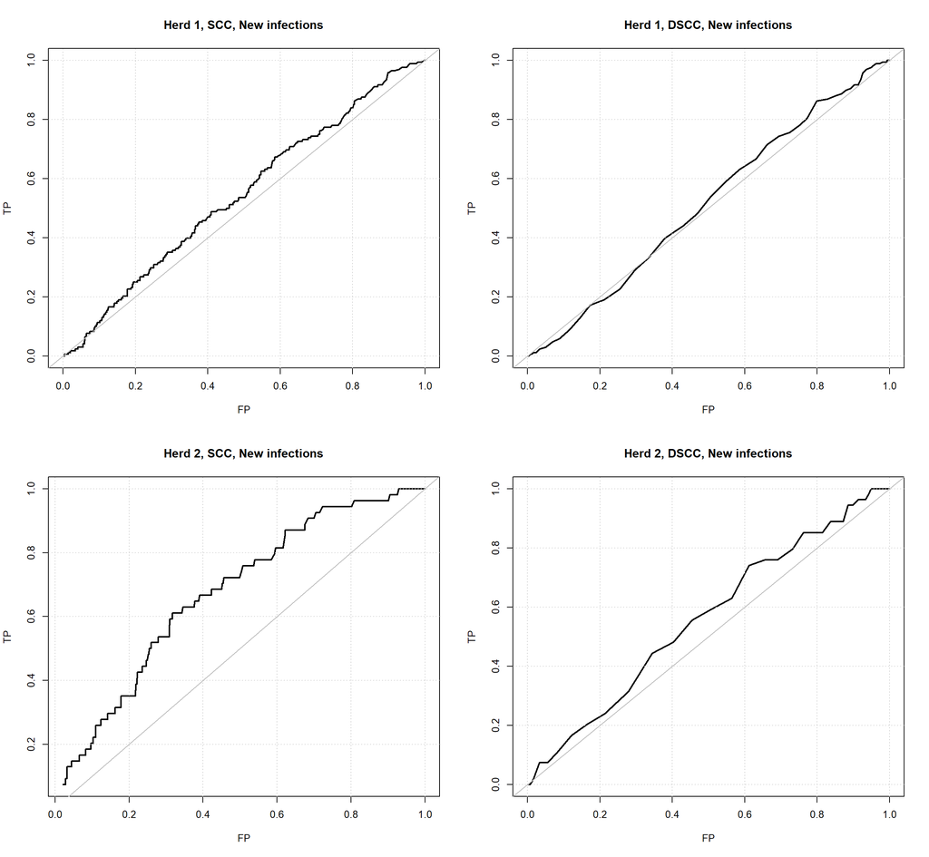

```r
par(mfrow=c(2,2))
plot(tp.h1.scc.ni ~ fp.h1.scc.ni, main="Herd 1, SCC, New infections", type="l", lwd=2, xlab="FP", ylab="TP")
grid()
abline(a=0, b=1, col="grey")
plot(tp.h1.dscc.ni ~ fp.h1.dscc.ni, main="Herd 1, DSCC, New infections", type="l", lwd=2, xlab="FP", ylab="TP")
grid()
abline(a=0, b=1, col="grey")
plot(tp.h2.scc.ni ~ fp.h2.scc.ni, main="Herd 2, SCC, New infections", type="l", lwd=2, xlab="FP", ylab="TP")
grid()
abline(a=0, b=1, col="grey")
plot(tp.h2.dscc.ni ~ fp.h2.dscc.ni, main="Herd 2, DSCC, New infections", type="l", lwd=2, xlab="FP", ylab="TP")
grid()
abline(a=0, b=1, col="grey")
```

For the chronic infections:

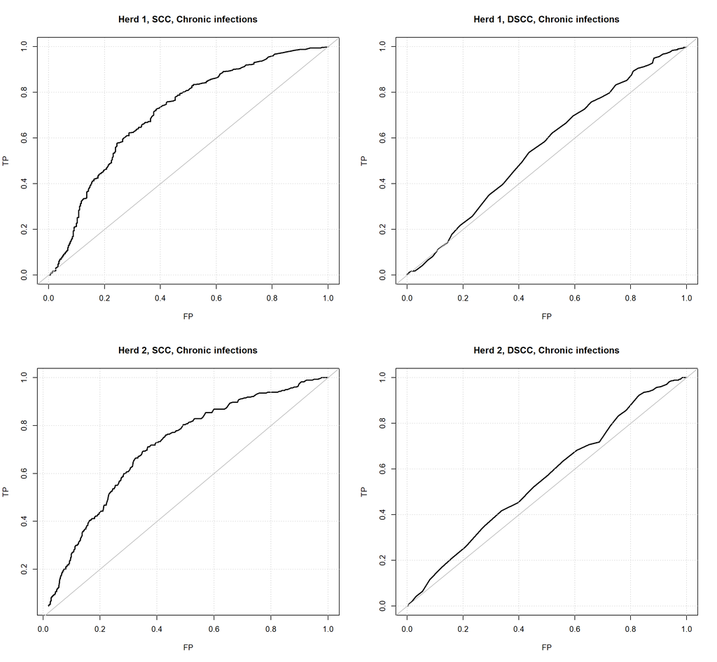

```r
par(mfrow=c(2,2))
plot(tp.h1.scc.ch ~ fp.h1.scc.ch, main="Herd 1, SCC, Chronic infections", type="l", lwd=2, xlab="FP", ylab="TP")
grid()
abline(a=0, b=1, col="grey")
plot(tp.h1.dscc.ch ~ fp.h1.dscc.ch, main="Herd 1, DSCC, Chronic infections", type="l", lwd=2, xlab="FP", ylab="TP")
grid()
abline(a=0, b=1, col="grey")
plot(tp.h2.scc.ch ~ fp.h2.scc.ch, main="Herd 2, SCC, Chronic infections", type="l", lwd=2, xlab="FP", ylab="TP")
grid()
abline(a=0, b=1, col="grey")
plot(tp.h2.dscc.ch ~ fp.h2.dscc.ch, main="Herd 2, DSCC, Chronic infections", type="l", lwd=2, xlab="FP", ylab="TP")
grid()
abline(a=0, b=1, col="grey")
```

Then we look at the combination of SCC and DSCC. At various SCC cutoffs, how do the roc curve look for SCC and vice versa?

Nået hertil

Jeg skal lave en 2x2 table for alle inf samlet først, med default cutoffs for SCC og DSCC. Og så skal jeg lave et ROC plan hvor jeg varierer cutoff for SCC og laver roc kurver for DSCC. ikke?

## SCC and DSCC for new / chronic infections

Then we look at the SCC and DSCC for chronic cows and new infections:

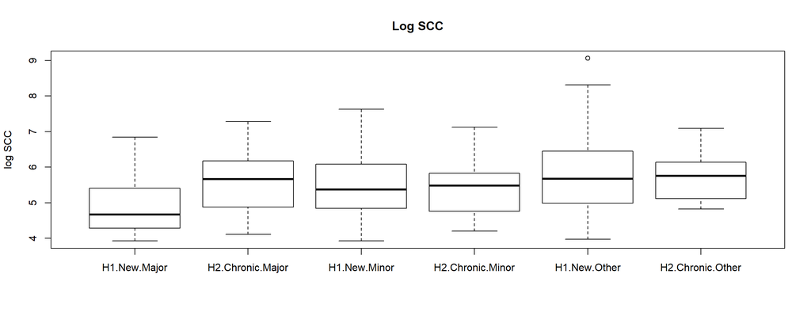

Figure 1: Boxplot of SCC for new and chronic infections

```r
alldata$logSCC <- log(alldata$SCC)
tmp1 <- list(H1.New.Major=alldata$logSCC[alldata$newinf.maj==1 & alldata$Herd%in%1],
                  H2.Chronic.Major=alldata$logSCC[alldata$newinf.maj==1 & alldata$Herd%in%2],
                  H1.New.Minor=alldata$logSCC[alldata$newinf.min==1 & alldata$Herd%in%1],
                  H2.Chronic.Minor=alldata$logSCC[alldata$newinf.min==1 & alldata$Herd%in%2],
                  H1.New.Other=alldata$logSCC[alldata$newinf.oth==1 & alldata$Herd%in%1],
                  H2.Chronic.Other=alldata$logSCC[alldata$newinf.oth==1 & alldata$Herd%in%2])
boxplot(tmp1, ylab="log SCC", ylab="Log SCC", main="Log SCC")
```

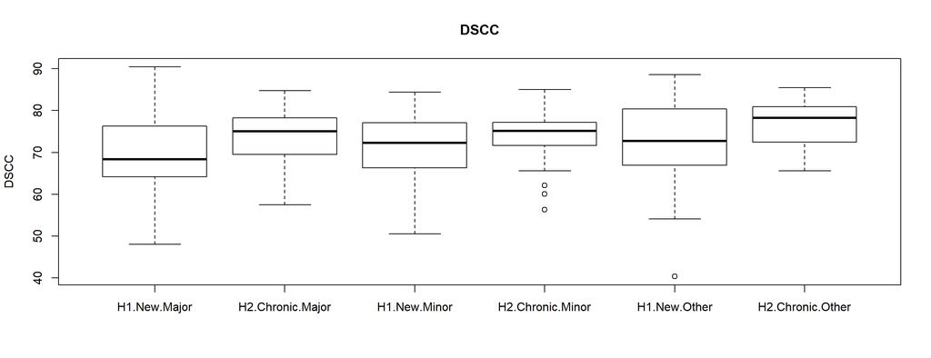

Figure 1: Boxplot of DSCC for new and chronic infections

```r
tmp2 <- list(H1.New.Major=alldata$DSCC[alldata$newinf.maj==1 & alldata$Herd%in%1],
                  H2.Chronic.Major=alldata$DSCC[alldata$newinf.maj==1 & alldata$Herd%in%2],
                  H1.New.Minor=alldata$DSCC[alldata$newinf.min==1 & alldata$Herd%in%1],
                  H2.Chronic.Minor=alldata$DSCC[alldata$newinf.min==1 & alldata$Herd%in%2],
                  H1.New.Other=alldata$DSCC[alldata$newinf.oth==1 & alldata$Herd%in%1],
                  H2.Chronic.Other=alldata$DSCC[alldata$newinf.oth==1 & alldata$Herd%in%2])
boxplot(tmp2, ylab="DSCC", ylab="DSCC", main="DSCC")
```

From a first glance, it looks like DSCC has more to offer for Minor and Other pathogens.

## Prediction models: New infections

Then we try to predict the chronic cows and the new infected cows:

```r
library(lme4)
alldata$logSCC.norm <- alldata$logSCC/max(alldata$logSCC, na.rm=TRUE)
alldata$DSCC.norm <- alldata$DSCC/max(alldata$DSCC, na.rm=TRUE)
alldata$DIM.norm <- alldata$DIM/max(alldata$DIM, na.rm=TRUE)
alldata$DIM2 <- alldata$DIM^2
alldata$DIM2.norm <- alldata$DIM2/max(alldata$DIM2, na.rm=TRUE)

#### Analyser Herd 1 ####

dt <- alldata[Herd%in%1,]

# Herd 1, major pathogens:
# model1 <- glmer(newinf.maj ~ par + DIM.norm + logSCC.norm + (1|Cow.ID) +
#                   DSCC.norm, data=dt,
#           na.action=na.omit, family = binomial(link = "logit"),
#                        control=glmerControl(optimizer="bobyqa",
#                                             optCtrl=list(maxfun=10000000)))
# model2 <- glmer(newinf.maj ~ par + DIM.norm + logSCC.norm + (1|Cow.ID), data=dt,
#           na.action=na.omit, family = binomial(link = "logit"),
#                        control=glmerControl(optimizer="bobyqa",
#                                             optCtrl=list(maxfun=10000000)))
# anova(model1, model2)
# # Ikke signifikant.
#
# # Herd 1, minor pathogens:
# model1 <- glmer(newinf.min ~ par + DIM.norm + logSCC.norm + (1|Cow.ID) +
#                   DSCC.norm, data=dt,
#           na.action=na.omit, family = binomial(link = "logit"),
#                        control=glmerControl(optimizer="bobyqa",
#                                             optCtrl=list(maxfun=10000000)))
# model2 <- glmer(newinf.min ~ par + DIM.norm + logSCC.norm + (1|Cow.ID), data=dt,
#           na.action=na.omit, family = binomial(link = "logit"),
#                        control=glmerControl(optimizer="bobyqa",
#                                             optCtrl=list(maxfun=10000000)))
# anova(model1, model2)
# # Ikke signifikant.
#
# # Herd 1, other pathogens:
# model1 <- glmer(newinf.oth ~ par + DIM.norm + logSCC.norm + (1|Cow.ID) +
#                   DSCC.norm, data=dt,
#           na.action=na.omit, family = binomial(link = "logit"),
#                        control=glmerControl(optimizer="bobyqa",
#                                             optCtrl=list(maxfun=10000000)))
# model2 <- glmer(newinf.oth ~ par + DIM.norm + logSCC.norm + (1|Cow.ID), data=dt,
#           na.action=na.omit, family = binomial(link = "logit"),
#                        control=glmerControl(optimizer="bobyqa",
#                                             optCtrl=list(maxfun=10000000)))
# anova(model1, model2)
# # Ikke signifikant.
#
# #### Analyser Herd 2 ####
#
# dt <- alldata[Herd%in%2,]
#
# # Herd 2, major pathogens:
# model1 <- glmer(newinf.maj ~ par + DIM.norm + logSCC.norm + (1|Cow.ID) +
#                   DSCC.norm, data=dt,
#           na.action=na.omit, family = binomial(link = "logit"),
#                        control=glmerControl(optimizer="bobyqa",
#                                             optCtrl=list(maxfun=10000000)))
# model2 <- glmer(newinf.maj ~ par + DIM.norm + logSCC.norm + (1|Cow.ID), data=dt,
#           na.action=na.omit, family = binomial(link = "logit"),
#                        control=glmerControl(optimizer="bobyqa",
#                                             optCtrl=list(maxfun=10000000)))
# anova(model1, model2)
# # Ikke signifikant.
#
# # Herd 2, minor pathogens:
# model1 <- glmer(newinf.min ~ par + DIM.norm + logSCC.norm + (1|Cow.ID) +
#                   DSCC.norm, data=dt,
#           na.action=na.omit, family = binomial(link = "logit"),
#                        control=glmerControl(optimizer="bobyqa",
#                                             optCtrl=list(maxfun=10000000)))
# model2 <- glmer(newinf.min ~ par + DIM.norm + logSCC.norm + (1|Cow.ID), data=dt,
#           na.action=na.omit, family = binomial(link = "logit"),
#                        control=glmerControl(optimizer="bobyqa",
#                                             optCtrl=list(maxfun=10000000)))
# anova(model1, model2)
# # Ikke signifikant.
#
# # Herd 2, other pathogens:
# model1 <- glmer(newinf.oth ~ par + DIM.norm + logSCC.norm + (1|Cow.ID) +
#                   DSCC.norm, data=dt,
#           na.action=na.omit, family = binomial(link = "logit"),
#                        control=glmerControl(optimizer="bobyqa",
#                                             optCtrl=list(maxfun=10000000)))
# model2 <- glmer(newinf.oth ~ par + DIM.norm + logSCC.norm + (1|Cow.ID), data=dt,
#           na.action=na.omit, family = binomial(link = "logit"),
#                        control=glmerControl(optimizer="bobyqa",
#                                             optCtrl=list(maxfun=10000000)))
# anova(model1, model2)
# Ikke signifikant.
```

I have made mixed models of the type:

*glmer(newinf.maj ~ par + DIM.norm + logSCC.norm + (1|Cow.ID), data=dt, na.action=na.omit, family = binomial(link = “logit”), control=glmerControl(optimizer=“bobyqa”, optCtrl=list(maxfun=10000000)))*

to explain new infections in one herd at a time, for one pathogen group at a time. DSCC did not bring added value in any of them.

## Prediction models: Chronic infections

Now we look at chronic cows:

```r
library(lme4)

#### Analyser Herd 1 ####

# dt <- alldata[Herd%in%1,]
#
# # Herd 1, major pathogens:
# model1 <- glmer(chronic.maj ~ par + DIM.norm + logSCC.norm + (1|Cow.ID) +
#                   DSCC.norm, data=dt,
#           na.action=na.omit, family = binomial(link = "logit"),
#                        control=glmerControl(optimizer="bobyqa",
#                                             optCtrl=list(maxfun=10000000)))
# model2 <- glmer(chronic.maj ~ par + DIM.norm + logSCC.norm + (1|Cow.ID), data=dt,
#           na.action=na.omit, family = binomial(link = "logit"),
#                        control=glmerControl(optimizer="bobyqa",
#                                             optCtrl=list(maxfun=10000000)))
# anova(model1, model2)
# # Ikke signifikant. p=0.09
#
# # Herd 1, minor pathogens:
# model1 <- glmer(chronic.min ~ par + DIM.norm + logSCC.norm + (1|Cow.ID) +
#                   DSCC.norm, data=dt,
#           na.action=na.omit, family = binomial(link = "logit"),
#                        control=glmerControl(optimizer="bobyqa",
#                                             optCtrl=list(maxfun=10000000)))
# model2 <- glmer(chronic.min ~ par + DIM.norm + logSCC.norm + (1|Cow.ID), data=dt,
#           na.action=na.omit, family = binomial(link = "logit"),
#                        control=glmerControl(optimizer="bobyqa",
#                                             optCtrl=list(maxfun=10000000)))
# anova(model1, model2)
# # Ikke signifikant.
#
# # Herd 1, other pathogens:
# model1 <- glmer(chronic.oth ~ par + DIM.norm + logSCC.norm + (1|Cow.ID) +
#                   DSCC.norm, data=dt,
#           na.action=na.omit, family = binomial(link = "logit"),
#                        control=glmerControl(optimizer="bobyqa",
#                                             optCtrl=list(maxfun=10000000)))
# model2 <- glmer(chronic.oth ~ par + DIM.norm + logSCC.norm + (1|Cow.ID), data=dt,
#           na.action=na.omit, family = binomial(link = "logit"),
#                        control=glmerControl(optimizer="bobyqa",
#                                             optCtrl=list(maxfun=10000000)))
# anova(model1, model2)
# # Ikke signifikant.
#
# #### Analyser Herd 2 ####
#
# dt <- alldata[Herd%in%2,]
#
# # Herd 2, major pathogens:
# model1 <- glmer(chronic.maj ~ par + DIM.norm + logSCC.norm + (1|Cow.ID) +
#                   DSCC.norm, data=dt,
#           na.action=na.omit, family = binomial(link = "logit"),
#                        control=glmerControl(optimizer="bobyqa",
#                                             optCtrl=list(maxfun=10000000)))
# model2 <- glmer(chronic.maj ~ par + DIM.norm + logSCC.norm + (1|Cow.ID), data=dt,
#           na.action=na.omit, family = binomial(link = "logit"),
#                        control=glmerControl(optimizer="bobyqa",
#                                             optCtrl=list(maxfun=10000000)))
# anova(model1, model2)
# # Ikke signifikant.
#
# # Herd 2, minor pathogens:
# model1 <- glmer(chronic.min ~ par + DIM.norm + logSCC.norm + (1|Cow.ID) +
#                   DSCC.norm, data=dt,
#           na.action=na.omit, family = binomial(link = "logit"),
#                        control=glmerControl(optimizer="bobyqa",
#                                             optCtrl=list(maxfun=10000000)))
# model2 <- glmer(chronic.min ~ par + DIM.norm + logSCC.norm + (1|Cow.ID), data=dt,
#           na.action=na.omit, family = binomial(link = "logit"),
#                        control=glmerControl(optimizer="bobyqa",
#                                             optCtrl=list(maxfun=10000000)))
# anova(model1, model2)
# # Ikke signifikant.
#
# # Herd 2, other pathogens:
# model1 <- glmer(chronic.oth ~ par + DIM.norm + logSCC.norm + (1|Cow.ID) +
#                   DSCC.norm, data=dt,
#           na.action=na.omit, family = binomial(link = "logit"),
#                        control=glmerControl(optimizer="bobyqa",
#                                             optCtrl=list(maxfun=10000000)))
# model2 <- glmer(chronic.oth ~ par + DIM.norm + logSCC.norm + (1|Cow.ID), data=dt,
#           na.action=na.omit, family = binomial(link = "logit"),
#                        control=glmerControl(optimizer="bobyqa",
#                                             optCtrl=list(maxfun=10000000)))
# anova(model1, model2)
# # Ikke signifikant.
```

I made the same models for chronic infected cows. DSCC did not bring any added value for those either.

Not even when using thw low SCC values.

## To do

#### Noter DSCC møde 26/11/2018

Vi bygger regressionsmodeller ligesom sidst med fire basis scenarioer: a) baseline b) SCC c) DSCC d) SCC + DSCC

1. Beholder dem med SCC <50K og sæt DSCC til halvdelen af den mindste værdi vi har.
2. Lav nye variable for SCC og DSCC:
- slope between two last measures, mean slope between three last measures. (Det giver mindre vægt til evt. outlier end Nicole Steeles metode)
- mean of 2, 3, 4 last measures…
- simple lag 1, 2, 3
- mean of x last + x last slopes
3. Ret falsk negative, men kun hvis det er samme patogen…!
4. Find kroniske og nye infektioner:
- Kronisk A: (mindst) 2 gange positiv
- kronisk B: (mindst) 3 gange positiv
- Nye infektioner: to negative og så positiv
5. Lav backwards elimination på de forskellige variable
- Både for kroniskA, kroniskB, nye of alle infektioner
- For hver patogen gruppe
6. Kunne vi ikke:
- DSCC x SCC x ml mælk = antal PMN+Lym ? Sikkert god til at finde new infections?
- (100-DSCC) x SCC x ml mælk = antal Macrophages ? Sikkert god til at finde chronic infections? Early infection: høj scc og mellem dscc pga både lym og mac går op? Late infection: mellem scc og lav dscc pga færre lym men stadig mange mac? After infection: lav scc og mellem dscc pga balance

## Data prep

This is where the code for data prep is in the Rmarkdown script. Not much to see in the rendered document.